# Earthquake clusters in catalog v5.1 (nearest-neighbour method)

Cascadia catalog v5.1 (NonLinLoc in model v0.3.1), 2010-2016, with the v5.1 Route A magnitudes (piece *mag*). Method of Zaliapin & Ben-Zion (2013a, 2016), same code and parameters as the catalog v4 analysis. Code: `workflow/06_analysis/v51_clusters_zbz.py`, `v51_swarms.py`, `v51_clusters_report.py`, branch `analysis/v51-clusters`, 2026-11-25. Private working product; not peer reviewed. Revised the same day after an independent review (null test, tier D errors, permutation migration test, family-level depth test, fault surfaces after their own fixes).

**Context.** Catalog v5.1 is located in model v0.3.1. The PI has adopted model v0.4.0 (D-B082); v0.4.1 (surface floor in the inversion, D-B083) is being built; catalog v6.0 (D-B079, NonLinLoc with SSST station terms) will supersede v5.1 and these products will be redone on it. A waveform review of four v5.1 location problems exists: Mount St Helens deep events (P1, probably false events from a weekly artificial signal on the analog UW channels HSR, EDM and STD, 2011-05 to 2013-08), Brookings 2012 (P2, NonLinLoc took the deeper of two S-P depth minima), tensor events (P3, a median 13.7 km deeper than ComCat) and far_only events (P4, moved from near the surface in v4 to 44-64 km). The main run uses epicentres only, so P2-P4 do not change links; P1 events are in the analysis set and their families are flagged.

## Summary

Of the 172,342 catalog rows, 168,406 are located earthquakes and go into the analysis. Left out: 623 rows without a hypocentre (loc_source none) and 3,313 events flagged as explosions, quarry blasts or other non-earthquakes. Above the regional completeness magnitude Mc there are 30,201 events (v4: 27,555); 62.3% of them are background singles (v4: 59.5%). The rest fall in 2,097 families (v4: 1,944): 994 mainshock-aftershock families (v4: 945), 200 swarms (v4: 177) and 903 doublets or small multiplets (v4: 822). With the events below Mc attached, 26,852 events (15.6% of all rows) are in a family (v4: 28,617).

## What changed from v4, and why

| region | Mc_v4 | Mc_v51 | b_v4 | b_v51 | events ≥ Mc v4 | events ≥ Mc v5.1 | NN dist v4 (km) | NN dist v5.1 (km) | log eta0 v4 | log eta0 v5.1 | % bg v4 | % bg v5.1 loc, v4.1 M | % bg v5.1 | families v4 | families v5.1 | swarms v4 | swarms v5.1 |
| --- | --- | --- | --- | --- | --- | --- | --- | --- | --- | --- | --- | --- | --- | --- | --- | --- | --- |
| AX | 0.75 | 0.65 | 0.77 | 0.72 | 4290 | 4410 | 1.29 | 0.79 | -5.47 | -6.11 | 50.60 | 60.90 | 61.80 | 404 | 356 | 40 | 40 |
| EN | 2.25 | 2.35 | 0.84 | 0.84 | 512 | 554 | 13.76 | 12.12 | -4.18 | -4.09 | 51.60 | 53.30 | 49.80 | 32 | 32 | 3 | 5 |
| BL | 2.45 | 2.45 | 1.27 | 1.27 | 6133 | 7230 | 2.56 | 2.57 | -6.86 | -6.89 | 50.20 | 51.20 | 52.50 | 497 | 578 | 62 | 70 |
| GO | 2.45 | 2.55 | 1.17 | 1.14 | 1150 | 1199 | 7.09 | 6.49 | -5.54 | -5.47 | 60.80 | 60.90 | 60.30 | 105 | 102 | 17 | 12 |
| MT | 1.85 | 1.95 | 1.06 | 1.06 | 7690 | 7412 | 18.41 | 18.18 | -5.34 | -5.39 | 57.50 | 57.10 | 57.50 | 373 | 379 | 15 | 13 |
| WA | 1.65 | 1.45 | 1.09 | 1.08 | 412 | 706 | 31.89 | 23.41 | -3.38 | -3.43 | 84.20 | 86.00 | 84.40 | 28 | 42 | 1 | 3 |
| OR | 1.85 | 1.85 | 1.01 | 0.89 | 389 | 398 | 33.24 | 30.56 | -3.25 | -3.22 | 68.40 | 73.00 | 75.60 | 31 | 24 | 0 | 0 |
| PU | 1.35 | 1.25 | 1.33 | 1.27 | 3245 | 3906 | 16.93 | 16.93 | -4.32 | -4.21 | 79.00 | 78.60 | 78.80 | 198 | 232 | 12 | 14 |
| ON | 1.75 | 1.65 | 0.93 | 0.81 | 3734 | 4386 | 9.59 | 8.90 | -3.97 | -3.66 | 69.40 | 69.70 | 69.60 | 276 | 352 | 27 | 43 |

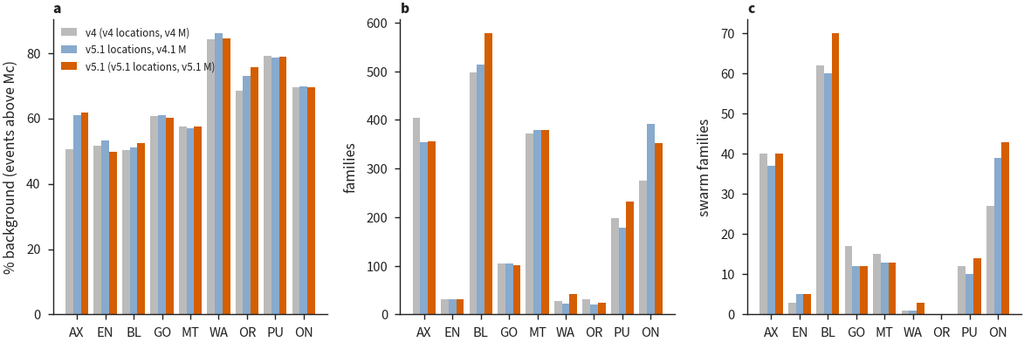

NN dist: median distance from each event above Mc to its nearest-neighbour parent. The middle bars and the '% bg v5.1 loc, v4.1 M' column are the variant `v41M`: v5.1 locations with the catalog v4.1 magnitudes, its own Mc and b. v4 used catalog v4 and the v4 Route A magnitudes.

**Three things changed between the runs: the events, the locations and the magnitudes.**

- **Events.** v5.1 leaves out 3,313 flagged non-earthquakes and 623 rows without a hypocentre; v4 kept all 172,340. Of the flagged events, 40 were in v4 families and 3,258 were v4 background. Catalog v4.1 also removed event 172113 and added 900001-900003 (the 2016-12-08 Mw 6.6 event and two 2016-01-30 M 5 events).
- **Magnitudes.** The v5.1 ML is higher by a median 0.05 (offshore 0.06; Axial -0.11). With the v4 Mc rule (maximum curvature + 0.2, largest yearly value) Mc changed by -0.10 to +0.10 in eight boxes and by -0.20 offshore Washington; the analysis set grew from 27,555 to 30,201 events. Comparing the v41M variant with the main run isolates the magnitude effect: it moves the background share by 0.1-3.5 points, and the labels of events in both analysis sets agree for 95.5-99.2%.
- **Locations.** Comparing v4 with the v41M variant isolates the location effect (and the event list). It is small everywhere except at Axial (+10.3 points) and offshore Oregon (+4.6 points, on 398 events). At Axial, the mixture threshold moved because the clustered and background modes of log eta moved by different amounts (-6.31 to -6.73 and -4.41 to -4.80) and the clustered weight dropped from 0.42 to 0.30. The share of events linked in time-shuffled catalogs at Axial dropped from 34% to 22%, but the real linked share dropped too: a shuffled catalog still links 75% as many Axial events as the real one.

### Event labels, v4 against v5.1 (all rows)

| cls4 | background | excluded_no_hypocentre | excluded_not_earthquake | family | linked_to_single | not in v5.1 | All |
| --- | --- | --- | --- | --- | --- | --- | --- |
| background | 130632 | 568 | 3258 | 2902 | 1394 | 1 | 138755 |
| family | 4719 | 49 | 40 | 23321 | 488 | 0 | 28617 |
| linked_to_single | 1274 | 6 | 15 | 628 | 3045 | 0 | 4968 |
| not in v4 | 2 | 0 | 0 | 1 | 0 | 0 | 3 |
| All | 136627 | 623 | 3313 | 26852 | 4927 | 1 | 172343 |

Rows: v4 class; columns: v5.1 class. 'family': in a family (above or below Mc); 'linked_to_single': a below-Mc event linked to a background single; 'background': no link. 2,902 v4 background events are now in families and 4,719 v4 family members are now background.

Events above Mc in both versions, background/family label v4 -> v5.1, by region:

| region_4 | background->background | background->family | family->background | family->family |
| --- | --- | --- | --- | --- |
| AX | 1867 | 97 | 497 | 1543 |
| BL | 2832 | 192 | 211 | 2829 |
| EN | 220 | 18 | 23 | 215 |
| GO | 601 | 35 | 40 | 398 |
| MT | 4007 | 171 | 189 | 2942 |
| ON | 2018 | 185 | 171 | 897 |
| OR | 193 | 8 | 43 | 79 |
| PU | 2144 | 78 | 74 | 594 |
| WA | 312 | 17 | 11 | 54 |

### Families kept, split, merged, new

Families are matched by shared event IDs (all members, including those attached below Mc). A v4 family is *kept* when one v5.1 family holds at least half of its members and at least half of that family's members come from it; *split* when two or more v5.1 families each hold at least 2 and at least 20% of its members; *merged* when its main v5.1 family also takes at least 20% of its members from another v4 family; *grown* when its main v5.1 family holds at least half of its members but is more than twice its size; *dissolved* when fewer than half of its members are in any v5.1 family. A v5.1 family is *new* when no v4 family contributes 2 members and 20% of its size.

v4 families by size (all members) and status:

| status | size | changed | dissolved | grown | kept | merged | split | All |
| --- | --- | --- | --- | --- | --- | --- | --- | --- |
|  | 2-4 | 0 | 243 | 43 | 775 | 36 | 3 | 1100 |
|  | 5-9 | 1 | 74 | 11 | 315 | 10 | 13 | 424 |
|  | 10-49 | 3 | 45 | 4 | 281 | 10 | 20 | 363 |
|  | 50+ | 4 | 1 | 0 | 47 | 0 | 5 | 57 |
|  | All | 8 | 363 | 58 | 1418 | 56 | 41 | 1944 |

v5.1 families by size and status:

| status | size | changed | grown | kept | merged | new | split_part | All |
| --- | --- | --- | --- | --- | --- | --- | --- | --- |
|  | 2-4 | 50 | 0 | 826 | 7 | 323 | 26 | 1232 |
|  | 5-9 | 31 | 15 | 329 | 15 | 58 | 25 | 473 |
|  | 10-49 | 13 | 7 | 259 | 14 | 22 | 21 | 336 |
|  | 50+ | 2 | 0 | 51 | 0 | 2 | 1 | 56 |
|  | All | 96 | 22 | 1465 | 36 | 405 | 73 | 2097 |

v4 families by region (box of the v4 largest event) and status:

| status | region | changed | dissolved | grown | kept | merged | split | All |
| --- | --- | --- | --- | --- | --- | --- | --- | --- |
|  | AX | 2 | 153 | 8 | 221 | 6 | 14 | 404 |
|  | BL | 1 | 53 | 17 | 399 | 14 | 13 | 497 |
|  | EN | 0 | 5 | 2 | 23 | 2 | 0 | 32 |
|  | GO | 1 | 13 | 5 | 82 | 2 | 2 | 105 |
|  | MT | 0 | 38 | 6 | 322 | 7 | 0 | 373 |
|  | ON | 4 | 55 | 16 | 177 | 15 | 9 | 276 |
|  | OR | 0 | 12 | 1 | 17 | 1 | 0 | 31 |
|  | PU | 0 | 28 | 2 | 158 | 7 | 3 | 198 |
|  | WA | 0 | 6 | 1 | 19 | 2 | 0 | 28 |
|  | All | 8 | 363 | 58 | 1418 | 56 | 41 | 1944 |

Type of kept families, v4 (rows) against v5.1 (columns):

| type_v51_main | type | mainshock-aftershock | multiplet | swarm | All |
| --- | --- | --- | --- | --- | --- |
|  | mainshock-aftershock | 646 | 25 | 15 | 686 |
|  | multiplet | 27 | 555 | 15 | 597 |
|  | swarm | 16 | 5 | 114 | 135 |
|  | All | 689 | 585 | 144 | 1418 |

Members of dissolved v4 families are now: background 1,189, linked_to_single 326, family 310, excluded_not_earthquake 40, excluded_no_hypocentre 24. Dissolved families are mostly small (doublets and triplets near the threshold); their members moved by a few km and their links crossed eta0. Large families that split or merged are listed below.

| v4 family | region | type | v4 members | start | status | main v5.1 family | shared | v5.1 members | v5.1 type | v5.1 parts |
| --- | --- | --- | --- | --- | --- | --- | --- | --- | --- | --- |
| 1051 | BL | mainshock-aftershock | 1274 | 2014-03-11 16:44:23.036546 | changed | 1170 | 477 | 480 | swarm | 1 |
| 860 | BL | swarm | 109 | 2013-10-14 08:43:11.641360 | split | 941 | 70 | 71 | swarm | 2 |
| 1766 | AX | swarm | 70 | 2015-04-24 19:36:34.845095 | split | 1882 | 26 | 44 | swarm | 2 |
| 64 | OR | mainshock-aftershock | 67 | 2010-07-28 16:12:04.546881 | dissolved | 79 | 30 | 34 | mainshock-aftershock | 1 |
| 1905 | PU | swarm | 65 | 2016-02-05 22:13:02.492995 | split | 2049 | 35 | 36 | swarm | 2 |
| 618 | GO | mainshock-aftershock | 59 | 2013-03-30 21:43:18.092165 | changed | 667 | 29 | 39 | mainshock-aftershock | 1 |
| 688 | ON | mainshock-aftershock | 58 | 2013-05-24 03:47:08.004326 | changed | 745 | 15 | 17 | mainshock-aftershock | 1 |
| 1461 | AX | swarm | 56 | 2015-02-14 22:54:19.885605 | changed | 1617 | 27 | 30 | swarm | 1 |
| 421 | BL | swarm | 55 | 2012-10-22 12:11:35.459323 | split | 455 | 28 | 29 | mainshock-aftershock | 2 |
| 1603 | AX | swarm | 55 | 2015-03-22 16:18:59.584586 | split | 1736 | 28 | 28 | swarm | 2 |

## Data and choices

**Events.** Catalog v5.1 (172,342 rows). Used: 168,406 located earthquakes (171,717 NonLinLoc locations and the 2 ComCat hypocentres of the v4.1 additions, minus 3,313 events with `is_earthquake` False: anss_explosion 1,665, quarry_blast_likely 1,572, anss_quarry_blast 74, both flags 1, anss_other_event 1). The 623 rows without a hypocentre are in the event table with role `excluded` and are not used anywhere.

**Poorly constrained depths.** floor_limited (8,053 used events), far_only (624) and deep_pass (356) events enter through their epicentres only: the main run uses epicentral distance, as in v4. Their depths are not used in the main run or in any depth statistic: depth ranges, depth migration and the 3-D variant `d3q` use only *depth_good* events (tier A-C, depth_quality ok, not floor_limited, far_only or deep_pass; 98,204 events). depth_quality 'unconstrained' (ridge regions, Blanco outside the 2012-13 OBS deployment) and 'biased_deep' (Gorda) are also left out of depth statistics. Three outputs do use every depth and are labelled so: variant `d3` (3-D distance with all depths, a sensitivity test), the family column `depth_main_any_quality` (depth of the largest event; check `depth_main_good`) and the DBSCAN columns `depth_any_quality_med` and `_iqr`. Because the main run uses epicentres only, the depth problems found by the waveform review (P2 Brookings, P3 tensor events a median 13.7 km deeper than ComCat, P4 far_only events moved from near the surface to 44-64 km) do not change any link; they enter depth statistics only where those events are depth_good.

**Tier D.** Tier D events stay in the analysis set, as all events did in v4; variant `tierABC` takes them out of it and attaches them afterwards. Their epicentres are reliable only at Axial. Median 68% horizontal semi-axis (h_max) of the events above Mc, links with a tier D end, and background shares:

| region | events ≥ Mc | tier D | % tier D | h_max tier D (km) | h_max tier A-C (km) | five-phase | h_max five-phase (km) | % bg tier D | % bg tier A-C | links | % links with a tier D end | % links with h_max ≥ 10 km | families led by a tier D event |
| --- | --- | --- | --- | --- | --- | --- | --- | --- | --- | --- | --- | --- | --- |
| AX | 4410 | 1494 | 33.9 | 4.8 | 1.8 | 28 | 59.7 | 81.2 | 51.9 | 1328 | 18.8 | 3.7 | 71 |
| EN | 554 | 111 | 20.0 | 36.0 | 4.1 | 23 | 52.2 | 72.1 | 44.2 | 246 | 13.4 | 40.2 | 1 |
| BL | 7230 | 574 | 7.9 | 28.0 | 1.9 | 158 | 36.8 | 73.9 | 50.6 | 2857 | 6.1 | 8.8 | 11 |
| GO | 1199 | 162 | 13.5 | 22.6 | 2.5 | 22 | 46.5 | 84.6 | 56.5 | 374 | 8.0 | 12.6 | 3 |
| MT | 7412 | 1067 | 14.4 | 9.1 | 1.7 | 84 | 36.5 | 54.0 | 58.1 | 2770 | 17.7 | 8.3 | 13 |
| WA | 706 | 168 | 23.8 | 45.1 | 1.7 | 43 | 58.3 | 97.0 | 80.5 | 68 | 5.9 | 5.9 | 3 |
| OR | 398 | 167 | 42.0 | 34.4 | 2.8 | 22 | 43.1 | 88.0 | 66.7 | 73 | 23.3 | 32.9 | 6 |
| PU | 3906 | 658 | 16.8 | 37.7 | 1.2 | 148 | 45.8 | 97.3 | 75.0 | 598 | 2.7 | 3.3 | 2 |
| ON | 4386 | 1781 | 40.6 | 31.9 | 3.6 | 464 | 42.1 | 72.9 | 67.3 | 985 | 47.9 | 57.1 | 110 |
| all | 30201 | 6182 | 20.5 | 21.7 | 1.8 | 992 | 42.2 | 75.7 | 58.8 | 9299 | 16.0 | 13.8 | 220 |

**Magnitudes.** The v5.1 Route A preferred magnitude M (ML calibrated to ComCat, tensor Mw above 4.5, Mw_cal). 41,337 used events have no M; they cannot be parents and are attached after the clustering (variant `noM_floor` gives them M = Mc).

**Regions, completeness, b.** The nine v4 boxes, applied to the v5.1 epicentres. Mc with the v4 rule: maximum curvature + 0.2 for each region and year with at least 200 events, the largest yearly value for the whole period. b by Aki (1965) above Mc. The mag piece's Mc_best (whole period, Woessner & Wiemer 2005 best rule) is lower by 0.05-0.45 because it does not take the worst year; it is variant `mc_best`.

| region | events | with M | Mc (all years) | Mc (b-stab.) | Mc used | Mc_best (mag piece) | years setting Mc | events ≥ Mc | b | b error | D2 epicentres | Mc_v4 | b_v4 |
| --- | --- | --- | --- | --- | --- | --- | --- | --- | --- | --- | --- | --- | --- |
| AX | 26874 | 13866 | 0.55 | 0.20 | 0.65 | 0.20 | 2014;2015;2016 | 4403 | 0.72 | 0.01 | 0.35 | 0.75 | 0.77 |
| EN | 2481 | 1874 | 2.25 | 2.00 | 2.35 | 1.90 | 2011;2012;2013;2014 | 554 | 0.84 | 0.04 | 1.18 | 2.25 | 0.84 |
| BL | 42728 | 31609 | 2.35 | 2.40 | 2.45 | 2.30 | 2012;2013;2014;2015 | 7217 | 1.27 | 0.02 | 0.96 | 2.45 | 1.27 |
| GO | 10251 | 7106 | 2.25 | 2.20 | 2.55 | 2.20 | 2011;2012;2013;2014;2015 | 1199 | 1.14 | 0.04 | 1.20 | 2.45 | 1.17 |
| MT | 38122 | 28658 | 1.65 | 1.80 | 1.95 | 1.70 | 2010;2011;2012;2013;2014;2015 | 7397 | 1.06 | 0.01 | 1.38 | 1.85 | 1.06 |
| WA | 3440 | 2773 | 1.25 | 1.20 | 1.45 | 1.20 | 2010;2011;2012;2013;2014;2015 | 703 | 1.08 | 0.04 | 1.36 | 1.65 | 1.09 |
| OR | 1721 | 1248 | 1.85 | 1.50 | 1.85 | 1.60 | 2012;2014;2015;2016 | 397 | 0.89 | 0.04 | 1.03 | 1.85 | 1.01 |
| PU | 13734 | 13044 | 1.15 | 1.20 | 1.25 | 1.20 | 2010;2011;2012;2013;2014;2015;2016 | 3892 | 1.27 | 0.02 | 1.48 | 1.35 | 1.33 |
| ON | 29055 | 26891 | 0.75 | 2.60 | 1.65 | 1.20 | 2010;2011;2012;2013;2014;2015;2016 | 4378 | 0.81 | 0.01 | 1.20 | 1.75 | 0.93 |

**The Mc rule depends on the bin edges.** The v4 code bins M with `np.arange(-2, 8, 0.1)`, whose edges are not exact decimals, so the few magnitudes that fall exactly on a 0.1 value go to the bin below. With exact edges (-2.0, -1.9, ...) Mc changes in 2 regions: BL 2.45 to 2.35 (7,230 to 9,539 events above Mc; the 2014 histogram that sets Mc has two largest bins of 774 and 766 events with the v4 edges and 769 and 769 with exact edges); OR 1.85 to 1.95 (398 to 346 events above Mc; the 2014 histogram that sets Mc has two largest bins of 21 and 20 events with the v4 edges and 21 and 20 with exact edges). Two near-equal modal bins decide Mc there. The run keeps the v4 edges so that v4 and v5.1 stay comparable; an exact-edge rerun would have to redo v4 the same way (`mc_edge_check.csv`).

**b sample.** b and the events ≥ Mc of this table come from the v4 function, which compares M with the unrounded Mc (a float error of a few 1e-15 above the nominal value), so the 61 events with M exactly at Mc (AX 7, BL 13, MT 15, WA 3, OR 1, PU 14, ON 8) are left out of b; the analysis set (`regions_zbz.csv`) includes them. With them b would be higher by at most 0.005, less than the b error (0.011-0.043). v4 computed b the same way, so the run keeps it for comparability.

**Inputs from the other v5.1 pieces** are read from their pushed branches, not from their worktrees: `data/catalog_v5/v5.1_analysis/faults/fault_surfaces_v1_assignment.csv.gz` at origin/analysis/v51-faults 6ebe0230; `data/catalog_v5/v5.1_analysis/faults/fault_surfaces_v1_summary.csv` at origin/analysis/v51-faults 6ebe0230; `data/catalog_v5/v5.1_analysis/mag/mc_b/mc_b_regional.csv` at origin/analysis/v51-mag cd0334d6.

**Proximity, threshold, families, classification.** Unchanged from v4: eta = t r^1.6 10^(-b m) (Baiesi & Paczuski 2004; Zaliapin et al. 2008) with t in years and r epicentral in km floored at 0.5 km, q = 0.5; parents in another region only within the rupture-length cap r ≤ max(10 km, 3 L(m)) (Wells & Coppersmith 1994); threshold eta0 where the two components of a Gaussian mixture on log eta cross, per region; links below eta0 and within the cap form trees (families); events below Mc or without M are attached to the nearest above-Mc parent if that link passes the same tests. Families of 2-4 events above Mc are multiplets when M1-M2 < 0.3, otherwise mainshock-aftershock; families of 5 or more are swarms when at least two of S1 (M1-M2 < 0.5), S2 (≥ 20% of events before the largest) and S3 (mean leaf depth ≥ 2 and fewer than half of the family direct offspring of the largest event) hold (topology criteria of Zaliapin & Ben-Zion 2013b, 2016; burst criteria of Vidale & Shearer 2006).

**Per-family migration and diffusion (new).** Computed on the tier A-C members (above and below Mc) of families with at least 10 of them. Origin: centroid of the first 10% of events (at least 3); r = epicentral distance from it, t = time since the first event. Spearman rho and Theil-Sen slope of r against t (radial speed); Theil-Sen slopes of east and north position against t give a velocity vector and its azimuth; depth migration from depth_good members. Diffusion: D90 = 90th percentile of r²/(4 pi t) over the events after the first 10% (the sqrt(4 pi D t) front of Shapiro et al. 1997 that encloses 90% of them). Envelope exponent p: slope of log r90 against log t over up to 8 log-time bins with at least 3 events each (p near 0.5 for diffusion, near 1 for constant-speed migration, near 0 for no growth). *Resolvable*: r90 at least twice the median 68% horizontal semi-axis (h_max) of the members. *Migrating*: rho ≥ 0.5, p < 0.01, positive radial slope and resolvable.

## Threshold and null test

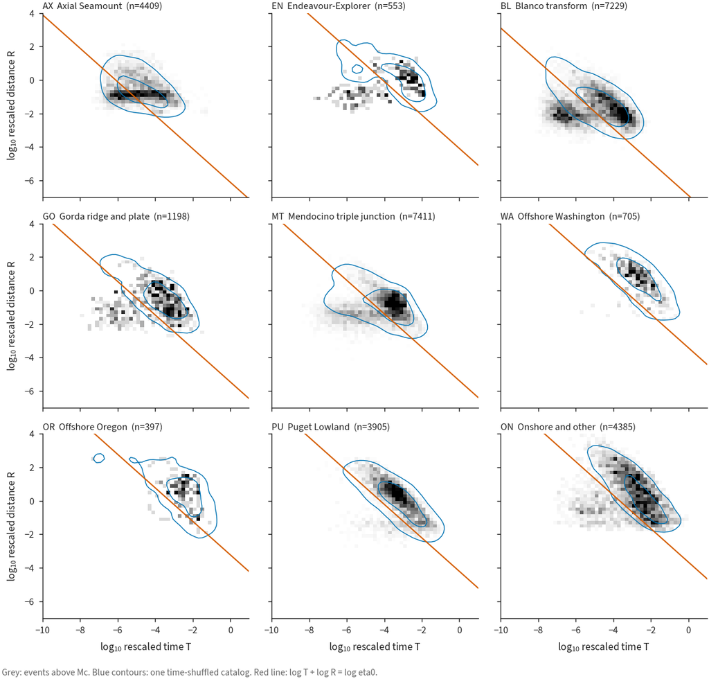

Density of rescaled time T and distance R of each event's nearest neighbour, events above Mc. Blue contours: one time-shuffled catalog (80% and 95% density levels). Red: threshold.

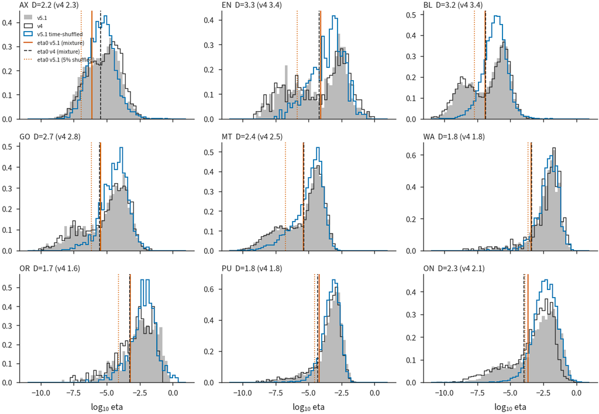

| region | w clust. | mu clust. | sd clust. | w bg | mu bg | sd bg | log eta0 | KDE valley | 5% shuffled | D | links < eta0 | cut by cap | log eta0 v4 | D_shuffled | % linked, shuffled | % linked, shuffled v4 |
| --- | --- | --- | --- | --- | --- | --- | --- | --- | --- | --- | --- | --- | --- | --- | --- | --- |
| AX | 0.30 | -6.73 | 0.77 | 0.70 | -4.80 | 0.95 | -6.11 | -6.73 | -6.91 | 2.23 | 1331 | 3 | -5.47 | 0.49 | 22.29 | 33.99 |
| EN | 0.50 | -6.16 | 1.30 | 0.50 | -2.62 | 0.78 | -4.09 | -4.43 | -5.85 | 3.31 | 272 | 26 | -4.18 | 1.78 | 13.06 | 12.83 |
| BL | 0.42 | -8.28 | 0.94 | 0.58 | -5.65 | 0.67 | -6.89 | -7.30 | -7.74 | 3.22 | 2981 | 124 | -6.86 | 0.35 | 14.96 | 15.64 |
| GO | 0.36 | -6.95 | 1.29 | 0.64 | -4.02 | 0.77 | -5.47 | -6.61 | -6.18 | 2.75 | 398 | 24 | -5.54 | 0.82 | 8.59 | 7.77 |
| MT | 0.43 | -6.84 | 1.35 | 0.57 | -4.36 | 0.56 | -5.39 | -6.46 | -6.76 | 2.41 | 2873 | 103 | -5.34 | 1.42 | 17.43 | 16.57 |
| WA | 0.16 | -4.22 | 1.64 | 0.84 | -1.98 | 0.62 | -3.43 | -4.22 | -3.67 | 1.81 | 85 | 17 | -3.38 | 1.34 | 2.74 | 2.59 |
| OR | 0.34 | -3.85 | 1.43 | 0.66 | -1.89 | 0.82 | -3.22 | -3.85 | -4.12 | 1.68 | 103 | 30 | -3.25 | 0.98 | 9.38 | 12.68 |
| PU | 0.23 | -5.05 | 1.46 | 0.77 | -3.04 | 0.54 | -4.21 | -5.05 | -4.53 | 1.82 | 715 | 117 | -4.32 | 1.30 | 4.51 | 4.78 |
| ON | 0.31 | -4.85 | 1.45 | 0.69 | -2.11 | 0.84 | -3.66 | -4.85 | -3.90 | 2.31 | 1145 | 160 | -3.97 | 1.02 | 4.48 | 6.11 |

**The mixture is not a test of clustering.** The threshold is where the two fitted Gaussian components of log eta cross. Their separation (Ashman D) is above 2 in AX, EN, BL, GO, MT, ON and below 2 in WA, OR, PU. A density valley between the two modes (kernel density minimum strictly between the two means) exists only in EN, BL, GO, MT; in AX, WA, OR, PU, ON the clustered component is a shoulder of one peak (column 'KDE valley' equals 'mu clust.'). As for shuffled catalogs, with the v4 mixture fit no shuffled catalog reaches the real D, but shuffled D depends on the seed and the kind of shuffle and reaches AX 2.19 (real 2.23), EN 3.12 (real 3.31), MT 2.21 (real 2.41); with a multi-start fit the reviewer found shuffled D of 5.35 at AX and 3.0 at OR. The first build said that all nine regions are bimodal and lose it when shuffled; that compared real D with the range of per-region means of three shuffles and does not hold seed by seed (its own seed 1 gave EN D = 2.90).

**Null test of the links.** The test that holds compares the share of events above Mc that are linked (below eta0 and within the cap) in the real catalog with the same share in time-shuffled catalogs at the real thresholds. Shuffled catalogs link fewer events in every region, but the ratio varies (table below): a shuffle over the whole period reproduces 75% of the Axial links, 48% offshore Oregon, 42% at the Mendocino triple junction, 39% on the Blanco and 21-30% in EN, GO, WA, PU, ON. Shuffled catalogs also form families and swarms: at Axial 311 families (real 356) and 14.5 swarms on average (real 40), on the Blanco 12.8 swarms (real 70), at the Mendocino triple junction 9.7 (real 13). Axial events above Mc sit in a 5 km caldera and most occur in the months of rising rate before the April 2015 eruption (Wilcock et al. 2016); a whole-period shuffle keeps the location and the event count of that period, so most Axial links and families are not evidence of clustering in time; the Axial swarm count is less affected. Shuffles that keep events in the same calendar year or month keep slow rate changes (network deployments, long sequences, the pre-eruption rise) and reproduce more: 33-77% of the links within the year and 62-92% within the month. At these thresholds most links join events that are close in space and fall in the same month; the timing within the month accounts for 8-38% of the links (most in BL). The links measure space-time concentration at the scale of weeks to months; on their own they are not evidence of short-term triggering.

| region | % linked, real | % linked, shuffled | shuffled / real (whole period) | shuffled / real (same year) | shuffled / real (same month) | D real | D shuffled min | D shuffled max | KDE valley real | % shuffles with valley | families real | families shuffled | swarms real | swarms shuffled (mean) | swarms shuffled (max) |
| --- | --- | --- | --- | --- | --- | --- | --- | --- | --- | --- | --- | --- | --- | --- | --- |
| AX | 30.11 | 22.61 | 0.75 | 0.77 | 0.79 | 2.23 | 0.27 | 0.61 | no | 0.00 | 356 | 311.30 | 40 | 14.50 | 21 |
| EN | 44.40 | 11.61 | 0.26 | 0.54 | 0.80 | 3.31 | 0.56 | 1.95 | yes | 0.00 | 32 | 31.30 | 5 | 0.40 | 2 |
| BL | 39.52 | 15.41 | 0.39 | 0.44 | 0.62 | 3.22 | 0.38 | 0.59 | yes | 0.00 | 578 | 359.10 | 70 | 12.80 | 16 |
| GO | 31.19 | 8.86 | 0.28 | 0.33 | 0.63 | 2.75 | 0.33 | 1.46 | yes | 0.00 | 102 | 45.20 | 12 | 0.10 | 1 |
| MT | 37.37 | 15.54 | 0.42 | 0.65 | 0.81 | 2.41 | 1.08 | 1.33 | yes | 0.00 | 379 | 266.50 | 13 | 9.70 | 15 |
| WA | 9.63 | 2.88 | 0.30 | 0.35 | 0.83 | 1.81 | 1.23 | 1.67 | no | 0.00 | 42 | 13.20 | 3 | 0.20 | 1 |
| OR | 18.34 | 8.77 | 0.48 | 0.67 | 0.92 | 1.68 | 0.78 | 1.50 | no | 0.00 | 24 | 10.50 | 0 | 0.10 | 1 |
| PU | 15.31 | 4.44 | 0.29 | 0.48 | 0.78 | 1.82 | 1.22 | 1.35 | no | 0.00 | 232 | 103.80 | 14 | 0.30 | 2 |
| ON | 22.46 | 4.66 | 0.21 | 0.41 | 0.75 | 2.31 | 0.92 | 1.28 | no | 0.00 | 352 | 137.90 | 43 | 1.30 | 4 |

Shuffles at the real thresholds and caps: 10 permutations of the event times within each region over 2010-2016, 5 within region and calendar year, 5 within region and month (step nulls, `null_test.csv`, `null_test_summary.csv`). Shuffled columns are means unless marked. The three shuffles of the shuffle step set the conservative threshold eta0_shuf5 and the figures above.

## Validation: known sequences

| label | expected | region | M | type | type_v4 | n ≥ Mc | v4 | n all | v4 | M2 | M2 v4 | t90 (d) | t90 v4 | extent (km) | leaf depth | leaf depth v4 |
| --- | --- | --- | --- | --- | --- | --- | --- | --- | --- | --- | --- | --- | --- | --- | --- | --- |
| 2010-01-10 Mw 6.5 Gorda | mainshock-aftershock | MT | 6.50 | mainshock-aftershock | mainshock-aftershock | 579 | 824.00 | 1668 | 2248.00 | 4.95 | 5.88 | 61.60 | 103.90 | 70.30 | 1.30 | 1.28 |
| 2014-03-10 Mw 6.8 Gorda | mainshock-aftershock | MT | 6.80 | mainshock-aftershock | mainshock-aftershock | 1239 | 1273.00 | 2358 | 2438.00 | 4.86 | 4.85 | 71.50 | 81.30 | 134.10 | 3.22 | 3.21 |
| 2011-09-09 Mw 6.4 Vancouver Island | mainshock-aftershock | ON | 6.41 | mainshock-aftershock | mainshock-aftershock | 133 | 144.00 | 229 | 344.00 | 4.57 | 4.63 | 57.70 | 372.70 | 33.00 | 1.23 | 1.00 |
| 2014-04-24 Mw 6.5 Vancouver Island | mainshock-aftershock | EN | 6.53 | mainshock-aftershock | mainshock-aftershock | 107 | 97.00 | 300 | 300.00 | 5.51 | 5.07 | 279.80 | 24.10 | 100.10 | 2.12 | 1.05 |
| 2012-11-08 Mw 6.1 Explorer plate | mainshock-aftershock | EN | 6.14 | mainshock-aftershock | mainshock-aftershock | 21 | 27.00 | 91 | 103.00 | 3.23 | 3.01 | 12.10 | 156.40 | 45.40 | 1.00 | 1.04 |
| 2015-01-28 Mw 5.7 Mendocino fault zone | mainshock-aftershock | MT | 5.71 | mainshock-aftershock | mainshock-aftershock | 90 | 90.00 | 682 | 672.00 | 4.54 | 4.29 | 63.00 | 57.10 | 40.10 | 3.09 | 1.12 |
| 2015-06-01 Mw 5.8, 5.4, 5.9 Blanco triplet | swarm or multiplet | BL | 5.80 | swarm | swarm | 101 | 77.00 | 744 | 755.00 | 5.80 | 5.80 | 31.90 | 20.60 | 46.30 | 1.58 | 1.61 |
| 2012-02/04 Mw 5.8 and 6.0 Blanco | swarm or multiplet | BL | 5.95 | swarm | swarm | 96 | 77.00 | 163 | 109.00 | 5.83 | 5.83 | 225.60 | 70.50 | 50.20 | 1.40 | 1.47 |
| 2016-12-08 Mw 6.6 Mendocino fracture zone (v4.1 addition) | mainshock-aftershock | GO | 6.60 | mainshock-aftershock |  | 4 |  | 4 |  | 4.71 |  | 16.90 |  | 74.20 | 1.00 |  |
| 2015-04-24 Axial Seamount eruption onset | swarm | AX | 4.30 | swarm | swarm | 495 | 632.00 | 513 | 805.00 | 4.19 | 4.16 | 0.60 | 1.20 | 6.90 | 37.46 | 23.93 |

All six large tectonic mainshocks are again mainshock-aftershock families, and the two Blanco pairs and triplets are again swarms with M1-M2 near 0.1. Two links changed. (1) The 2010-02-04 Mw 5.9 event, 44 km south of the 2010-01-10 Mw 6.5 Gorda event in v4, is 54 km from it in v5.1; its link (log eta -5.27) now misses the MT threshold (-5.39) and it heads its own family, so the 2010 family has M2 4.95 instead of 5.88 and 579 instead of 824 events above Mc. (2) The 2014-04-24 Mw 6.5 Vancouver Island family now starts with the 2013-08-04 M 5.5 event (ID 64836), linked as a foreshock 263 days earlier: t90 grows from 24 to 280 days and the mean leaf depth from 1.05 to 2.12. This link is a location artefact. Event 64836 is tier D (h_max 24 km, 8 stations, azimuthal gap 260 deg). It sits 1.1 km from the mainshock epicentre in v5.1 but 32.8 km away in v4; the small v5.1 separation is far inside its location error. In variant tierABC the 2014 family is an ordinary mainshock-aftershock sequence without it (73 events above Mc, t90 16 days, mean leaf depth 1.18). The 2016-12-08 Mw 6.6 event (added in v4.1) has only 23 days of catalog after it and 4 events above Mc in its family.

Other known sequences changed shape without changing type: 2011-09-09 Mw 6.4 Vancouver Island: t90 373 to 58 days (without tier D: t90 133 days); 2012-11-08 Mw 6.1 Explorer plate: t90 156 to 12 days (without tier D: t90 11 days); 2015-01-28 Mw 5.7 Mendocino fault zone: mean leaf depth 1.12 to 3.09 (without tier D: leaf depth 1.15); 2012-02/04 Mw 5.8 and 6.0 Blanco: t90 70 to 226 days (without tier D: t90 237 days); 2015-04-24 Axial Seamount eruption onset: mean leaf depth 23.93 to 37.46. Where the values without tier D (variant tierABC) are close to v4, tier D members drive the change; elsewhere it comes from links of tier A-C events near the threshold. The table below gives the largest other member of each family, its location quality, and the same family without tier D.

| label | type | n ≥ Mc | largest other member | its M | its time | tier | h_max (km) | stations | gap (deg) | distance v5.1 (km) | distance v4 (km) | type, tierABC | n, tierABC | t90, tierABC (d) | leaf depth, tierABC |
| --- | --- | --- | --- | --- | --- | --- | --- | --- | --- | --- | --- | --- | --- | --- | --- |
| 2010-01-10 Mw 6.5 Gorda | mainshock-aftershock | 579 | 339.00 | 4.95 | 2010-01-10 02:21:39 | C | 3.80 | 40.00 | 233.00 | 27.60 | 9.20 | mainshock-aftershock | 320.00 | 69.10 | 1.33 |
| 2014-03-10 Mw 6.8 Gorda | mainshock-aftershock | 1239 | 83696.00 | 4.86 | 2014-03-10 05:20:28 | C | 5.10 | 17.00 | 281.00 | 33.70 | 25.20 | mainshock-aftershock | 1177.00 | 70.00 | 3.23 |
| 2011-09-09 Mw 6.4 Vancouver Island | mainshock-aftershock | 133 | 19962.00 | 4.57 | 2011-09-09 19:44:44 | C | 7.80 | 31.00 | 172.00 | 7.40 | 2.70 | mainshock-aftershock | 59.00 | 132.70 | 1.16 |
| 2014-04-24 Mw 6.5 Vancouver Island | mainshock-aftershock | 107 | 64836.00 | 5.51 | 2013-08-04 13:22:27 | D | 24.00 | 8.00 | 260.00 | 1.10 | 32.80 | mainshock-aftershock | 73.00 | 15.80 | 1.18 |
| 2012-11-08 Mw 6.1 Explorer plate | mainshock-aftershock | 21 | 40598.00 | 3.23 | 2012-11-08 21:07:35 | C | 4.20 | 17.00 | 192.00 | 10.70 | 3.80 | mainshock-aftershock | 19.00 | 11.00 | 1.00 |
| 2015-01-28 Mw 5.7 Mendocino fault zone | mainshock-aftershock | 90 | 114954.00 | 4.54 | 2015-01-14 10:44:34 | A | 1.10 | 69.00 | 127.00 | 3.20 | 3.00 | mainshock-aftershock | 82.00 | 49.80 | 1.15 |
| 2015-06-01 Mw 5.8, 5.4, 5.9 Blanco triplet | swarm | 101 | 150362.00 | 5.89 | 2015-06-01 20:11:28 | C | 3.30 | 25.00 | 215.00 | 15.50 | 18.70 | swarm | 94.00 | 30.80 | 1.61 |
| 2012-02/04 Mw 5.8 and 6.0 Blanco | swarm | 96 | 25512.00 | 5.83 | 2012-02-15 03:31:16 | C | 2.90 | 83.00 | 62.00 | 2.40 | 2.20 | swarm | 93.00 | 237.00 | 1.41 |
| 2016-12-08 Mw 6.6 Mendocino fracture zone (v4.1 addition) | mainshock-aftershock | 4 | 172114.00 | 4.71 | 2016-12-08 16:32:47 | C | 4.10 | 51.00 | 293.00 | 12.60 |  | mainshock-aftershock | 2.00 | 0.10 | 1.00 |
| 2015-04-24 Axial Seamount eruption onset | swarm | 495 |  |  |  |  |  |  |  |  |  |  |  |  |  |

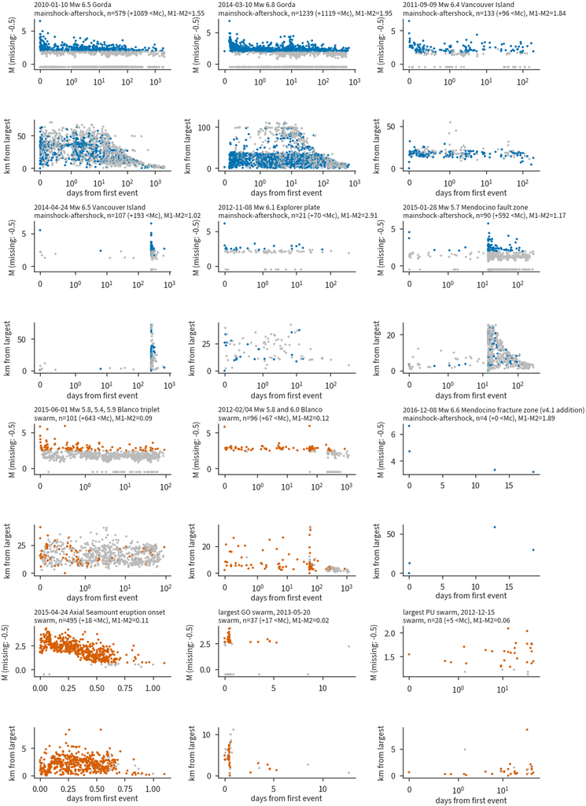

Magnitude and distance from the largest event against time. Coloured: events above Mc; grey: attached events below Mc (missing M at -0.5).

## Families: depth, migration, swarms

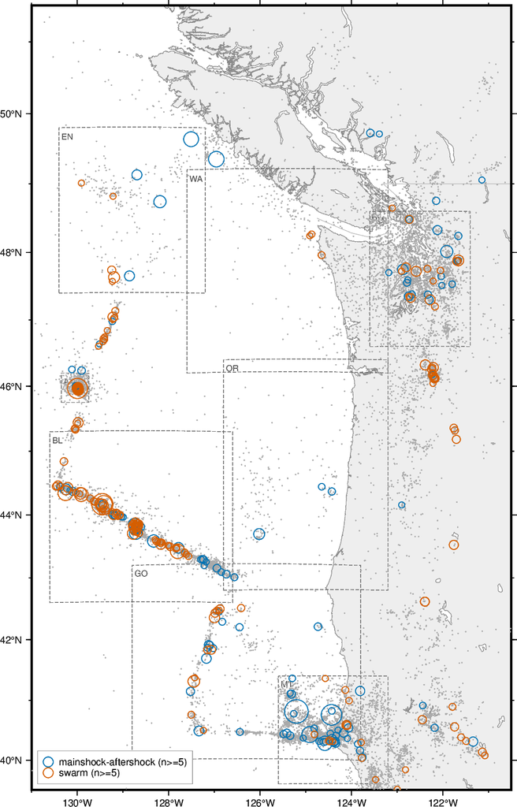

Families with 5 or more events above Mc at their largest event, sized by log n; grey dots: background events above Mc. Dashed boxes: regions.

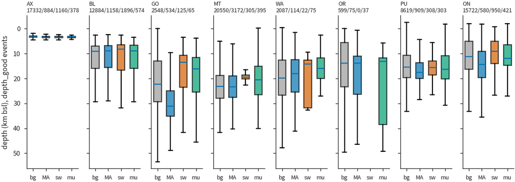

Depth of depth_good events by class (bg background, MA mainshock-aftershock, sw swarm, mu multiplet; all events, above and below Mc); counts above each panel. EN has too few depth_good events.

Median depth (km below sea level) of depth_good events by class:

| c | region | background | linked_to_single | mainshock-aftershock | multiplet | swarm |
| --- | --- | --- | --- | --- | --- | --- |
|  | AX | 3.2 | 3.2 | 3.4 | 3.3 | 3.4 |
|  | EN | 30.6 |  | 27.4 |  |  |
|  | BL | 9.0 | 9.0 | 9.0 | 9.0 | 8.2 |
|  | GO | 22.2 | 26.2 | 31.0 | 16.0 | 13.4 |
|  | MT | 23.2 | 20.9 | 23.3 | 20.6 | 19.4 |
|  | WA | 19.8 | 20.9 | 18.1 | 16.0 | 14.2 |
|  | OR | 13.8 | 16.6 | 13.8 | 13.2 |  |
|  | PU | 15.5 | 15.4 | 17.4 | 16.3 | 15.6 |
|  | ON | 11.1 | 10.9 | 14.4 | 12.0 | 9.0 |

**Swarm and mainshock-aftershock depths.** Events of one family are not independent, so the comparison uses families as the unit: the median depth of each family's depth_good members (families with at least 3), compared by a Mann-Whitney test per region. Swarm families are shallower than mainshock-aftershock families in GO (9.1 against 25.3 km, 8 and 17 families, p = 0.004), MT (19.4 against 25.4 km, 13 and 132 families, p = 0.016), ON (8.3 against 12.9 km, 21 and 48 families, p = 0.019). After a Bonferroni correction over the 7 regions tested only GO stays below 0.05. AX, BL, WA, PU show no significant difference (p 0.97, 0.07, 0.84, 0.63). Without the review sets P1 (Mount St Helens deep events) and P3 (tensor events) the p-values are GO 0.004, MT 0.016, ON 0.021. The event-level medians of the first build (GO 13.4 against 31.0 km, ON 9.0 against 14.4, MT 19.4 against 23.3) weight large families heavily and are not a test. In the Puget box, 94% of the depth_good events above Mc at 30 km or deeper (intraslab) are background, against 73% above 30 km.

| events used | region | swarm families | MA families | swarm (median of family medians, km) | MA (median of family medians, km) | swarm events (km) | MA events (km) | p | p Bonferroni |
| --- | --- | --- | --- | --- | --- | --- | --- | --- | --- |
| all | AX | 38 | 116 | 3.3 | 3.4 | 3.4 | 3.4 | 0.972 | 1 |
| all | EN | 0 | 1 |  | 31.7 |  | 30.5 |  |  |
| all | BL | 28 | 94 | 8.3 | 10.3 | 8.2 | 9 | 0.0706 | 0.494 |
| all | GO | 8 | 17 | 9.1 | 25.3 | 13.4 | 31 | 0.0039 | 0.0271 |
| all | MT | 13 | 132 | 19.4 | 25.4 | 19.4 | 23.3 | 0.0157 | 0.11 |
| all | WA | 3 | 12 | 13.1 | 14.7 | 14.2 | 17.8 | 0.84 | 1 |
| all | OR | 0 | 6 |  | 12.5 |  | 13.8 |  |  |
| all | PU | 14 | 72 | 14.5 | 14.8 | 15.6 | 17.2 | 0.627 | 1 |
| all | ON | 21 | 48 | 8.3 | 12.9 | 9 | 14.4 | 0.0192 | 0.135 |
| without_P1_P3 | AX | 38 | 116 | 3.3 | 3.4 | 3.4 | 3.4 | 0.972 | 1 |
| without_P1_P3 | EN | 0 | 1 |  | 31.7 |  | 30.5 |  |  |
| without_P1_P3 | BL | 28 | 94 | 8.3 | 10.3 | 8.2 | 9 | 0.0715 | 0.501 |
| without_P1_P3 | GO | 8 | 17 | 9.1 | 25.3 | 13.4 | 31 | 0.0039 | 0.0271 |
| without_P1_P3 | MT | 13 | 132 | 19.4 | 25.3 | 19.4 | 23.2 | 0.016 | 0.112 |
| without_P1_P3 | WA | 3 | 12 | 13.1 | 14.7 | 14.2 | 17.5 | 0.84 | 1 |
| without_P1_P3 | OR | 0 | 6 |  | 12.5 |  | 13.8 |  |  |
| without_P1_P3 | PU | 14 | 72 | 14.5 | 14.8 | 15.6 | 17.2 | 0.627 | 1 |
| without_P1_P3 | ON | 21 | 47 | 8.3 | 13 | 8.9 | 14.3 | 0.0209 | 0.146 |

### Migration and diffusion

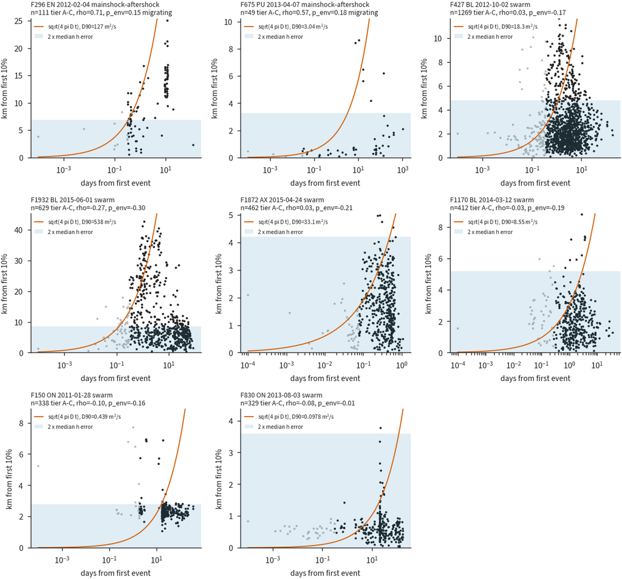

Distance from the centroid of the first 10% of events (grey) against time for the migrating families and the largest swarms. Red: the sqrt(4 pi D90 t) front; blue band: twice the median horizontal error, below which distances are not resolved.

Families that migrate by our test (4). The test uses a one-sided permutation p-value of the radial Spearman rho (2,000 permutations of the positions against the times, the origin recomputed each time), because taking the origin from the first 10% of the same events biases the ordinary Spearman p-value toward migration. Family 1396 (PU, 2014-09-17, mainshock-aftershock, 18 tier A-C members) passes with the Spearman p-value (0.009) but not with the permutation test (p = 0.018).

| family_id | region | region_v51 | type | start | n | n_all | n A-C | Mmax | days | rho | Spearman p | permutation p | radial km/d | azimuth | speed km/d | vz km/d | D90_m2s | env_p | h err | r90 km | style | v4_status |
| --- | --- | --- | --- | --- | --- | --- | --- | --- | --- | --- | --- | --- | --- | --- | --- | --- | --- | --- | --- | --- | --- | --- |
| 296 | EN | Explorer | mainshock-aftershock | 2012-02-04 12:27:05.925604 | 45 | 132 | 111 | 5.59 | 122.18 | 0.71 | 0.00 | 0.00 | 0.78 | 16.74 | 1.36 |  | 127.22 | 0.15 | 3.45 | 15.88 | slower than sqrt(t) | kept |
| 400 | ON | Cascades | swarm | 2012-09-10 17:21:36.464717 | 5 | 19 | 11 | 3.23 | 40.65 | 0.91 | 0.00 | 0.00 | 0.22 | 329.20 | 0.22 | 0.15 | 5.93 |  | 3.18 | 8.65 | too few events for the envelope | split_part |
| 675 | PU | Puget/Georgia | mainshock-aftershock | 2013-04-07 08:57:07.276732 | 14 | 52 | 49 | 3.42 | 1055.91 | 0.57 | 0.00 | 0.00 | 0.00 | 24.90 | 0.00 | -0.03 | 3.04 | 0.18 | 1.63 | 4.46 | slower than sqrt(t) | kept |
| 989 | GO | Gorda | swarm | 2013-11-13 10:47:04.408695 | 14 | 19 | 16 | 3.67 | 0.38 | 0.75 | 0.00 | 0.00 | 37.54 | 231.84 | 41.89 |  | 719.73 |  | 3.82 | 12.47 | too few events for the envelope | kept |

The 2012-02-04 M 5.6 Explorer sequence (EN) is the clearest case, as in v4: its aftershock zone grows north-northeast at about 0.8 km/day over four months, but its envelope exponent p = 0.15 is far below 0.5, so the growth is fast early and slows; neither a constant speed nor a sqrt(t) front describes it. The 2013-11-13 Gorda swarm moves about 40 km/day over 9 hours (16 tier A-C events), a dike-like speed, but on few events. The v4 example of the 2013-05-20 Escanaba Trough swarm (10 km/day in v4) is family 736 in v5.1 with rho 0.46: below our cut.

Most swarms are compact relative to their location errors: the median swarm with 10 or more tier A-C members has a 90% radius of 2.2 km and a median horizontal error of 2.0 km. D90 values for those swarms (16-157 m²/s interquartile) are therefore upper bounds set by scatter divided by short durations, not hydraulic diffusivities. Testing fluid-diffusion triggering needs relative relocation (double difference) of the swarms.

### Swarms with 20 or more events

| family_id | region | region_v51 | start | t90 ≥Mc (d) | duration all (d) | n ≥ Mc | n_all | M_range | n depth_good | depth 10-90% (km) | extent km | long axis az | rho | radial km/d | mig. az | env_p | resolvable | D90 m2/s (resolvable only) | on faults | main surface | v4_status |
| --- | --- | --- | --- | --- | --- | --- | --- | --- | --- | --- | --- | --- | --- | --- | --- | --- | --- | --- | --- | --- | --- |
| 427 | BL | Blanco | 2012-10-02 11:47:03.047552 | 3.43 | 187.07 | 683 | 1447 | 1.2 - 4.9 | 1241 | 5.0 - 20.9 | 16.49 | 161.34 | 0.03 | 0.01 | 342.86 | -0.17 | True | 18.3 | 0.75 | v1_BL001 | kept |
| 1932 | BL | Blanco | 2015-06-01 06:52:39.659996 | 31.90 | 93.38 | 101 | 744 | 0.8 - 5.9 | 0 |  | 46.27 | 110.15 | -0.27 | -0.08 | 104.14 | -0.30 | True | 538.3 | 0.69 | v1_BL002 | kept |
| 1872 | AX | Axial | 2015-04-24 05:13:16.173002 | 0.60 | 1.10 | 495 | 513 | 0.3 - 4.3 | 455 | 2.6 - 4.2 | 6.91 | 153.90 | 0.03 | 0.12 | 198.34 | -0.21 | False |  |  |  | kept |
| 1170 | BL | Blanco | 2014-03-12 04:17:39.936356 | 4.32 | 36.37 | 192 | 480 | 1.6 - 4.3 | 0 |  | 9.28 | 14.25 | -0.03 | -0.01 | 93.31 | -0.19 | False |  | 0.63 | v1_BL001 | changed |
| 150 | ON | Cascades | 2011-01-28 00:44:22.552693 | 18.22 | 366.43 | 20 | 358 | -0.3 - 3.9 | 332 | 4.1 - 5.7 | 21.39 | 174.47 | -0.10 | -0.00 | 34.40 | -0.16 | False |  | 0.91 | v1_ON002 | kept |
| 830 | ON | Cascades | 2013-08-03 02:11:16.072637 | 98.30 | 179.11 | 23 | 338 | 0.0 - 3.5 | 329 | 13.1 - 14.6 | 1.11 | 122.95 | -0.08 | -0.00 | 136.15 | -0.01 | False |  | 0.00 |  | kept |
| 302 | BL | Blanco | 2012-02-15 03:31:16.100627 | 225.57 | 1203.02 | 96 | 163 | 1.4 - 6.0 | 49 | 9.5 - 23.6 | 50.24 | 119.67 | -0.31 | -0.00 | 296.72 | -0.22 | True | 10.4 | 0.72 | v1_BL005 | kept |
| 1066 | EN | JdF ridge/plate | 2014-01-09 19:58:59.290156 | 6.08 | 98.23 | 30 | 146 | 1.5 - 3.9 | 0 |  | 7.92 | 24.88 | -0.16 | -0.02 | 26.26 | -0.10 | False |  | 0.00 |  | kept |
| 754 | BL | Blanco | 2013-05-25 04:36:16.571807 | 9.02 | 65.07 | 39 | 131 | 1.5 - 4.5 | 119 | 5.0 - 19.2 | 11.10 | 120.41 | -0.25 | -0.08 | 109.68 | -0.15 | True | 212.2 | 0.75 | v1_BL001 | kept |
| 1105 | BL | Blanco | 2014-02-02 11:47:14.708747 | 1.65 | 3.40 | 75 | 131 | 1.5 - 4.2 | 0 |  | 11.03 | 5.25 | 0.08 | 0.10 | 112.15 | 0.07 | False |  | 0.63 | v1_BL001 | kept |
| 1347 | MT | Offshore forearc | 2014-07-16 06:51:30.534261 | 7.49 | 11.17 | 12 | 109 | 1.0 - 3.1 | 101 | 18.5 - 20.1 | 3.85 | 124.65 | -0.13 | -0.03 | 327.27 | -0.07 | False |  | 0.93 | v1_MT001 | kept |
| 1165 | BL | Blanco | 2014-03-11 16:44:21.593175 | 1.66 | 10.05 | 42 | 104 | 1.8 - 4.0 | 0 |  | 9.72 | 124.72 | 0.05 | 0.05 | 300.01 | 0.07 | False |  | 0.78 | v1_BL001 | changed |
| 941 | BL | Blanco | 2013-10-14 17:55:24.685959 | 0.47 | 0.95 | 38 | 71 | 2.0 - 4.0 | 0 |  | 9.29 | 23.21 | 0.36 | 3.43 | 21.13 | 0.30 | True | 67.0 | 0.66 | v1_BL006 | split_part |
| 1315 | MT | Offshore forearc | 2014-06-10 19:46:14.058488 | 4.30 | 13.56 | 16 | 70 | 1.1 - 3.4 | 64 | 17.3 - 21.1 | 7.19 | 127.20 | -0.11 | -0.04 | 286.60 | -0.05 | False |  | 0.90 | v1_MT001 | kept |
| 1130 | BL | Blanco | 2014-02-14 05:26:14.035540 | 0.23 | 0.45 | 22 | 67 | 2.1 - 4.0 | 0 |  | 9.25 | 122.44 | -0.10 | -1.08 | 28.40 | -0.08 | False |  | 0.90 | v1_BL005 | kept |
| 431 | PU | Puget/Georgia | 2012-10-05 20:32:10.373732 | 81.67 | 140.60 | 22 | 59 | 0.6 - 2.7 | 55 | 14.2 - 19.0 | 3.25 | 120.63 | -0.09 | -0.00 | 353.13 |  | False |  | 0.86 | v1_PU002 | kept |
| 1744 | AX | Axial | 2015-03-23 22:08:39.953010 | 0.08 | 0.12 | 26 | 59 | 0.1 - 3.0 | 36 | 3.6 - 5.1 | 2.32 | 1.53 | 0.33 | 3.32 | 66.40 | 0.18 | False |  |  |  | kept |
| 1792 | AX | Axial | 2015-04-01 13:49:50.453934 | 0.04 | 0.07 | 14 | 57 | -0.1 - 2.4 | 56 | 2.8 - 3.7 | 0.93 | 112.78 | 0.03 | 0.00 | 191.52 | -0.23 | False |  |  |  | kept |
| 1300 | BL | Blanco | 2014-05-27 00:55:59.613918 | 1.05 | 5.25 | 20 | 56 | 1.9 - 3.8 | 0 |  | 7.60 | 36.70 | 0.10 | 0.18 | 65.25 | 0.17 | False |  | 0.38 | v1_BL004 | kept |
| 736 | GO | Gorda | 2013-05-20 02:11:20.712944 | 3.81 | 12.68 | 37 | 54 | 2.2 - 4.0 | 34 | 11.2 - 13.8 | 9.99 | 169.04 | 0.46 | 0.65 | 207.21 |  | True | 46.1 | 0.76 | v1_GO004 | kept |
| 1564 | AX | Axial | 2015-01-31 00:34:37.445302 | 0.02 | 0.26 | 13 | 54 | -0.5 - 3.5 | 54 | 2.9 - 3.7 | 1.48 | 156.35 | 0.31 | 2.05 | 152.23 | 0.22 | False |  |  |  | kept |
| 1948 | BL | Blanco | 2015-06-28 08:47:43.751672 | 0.07 | 0.53 | 7 | 50 | 1.6 - 3.4 | 0 |  | 9.03 | 44.94 | -0.11 | -2.37 | 289.35 | -0.26 | False |  | 0.38 | v1_BL012 | kept |
| 988 | BL | Blanco | 2013-11-11 23:04:56.273292 | 0.52 | 1.90 | 19 | 50 | 1.8 - 3.3 | 0 |  | 4.00 | 174.64 | 0.21 | 0.27 | 353.80 | -0.05 | False |  | 0.88 | v1_BL004 | kept |
| 1326 | BL | Blanco | 2014-06-19 18:53:37.906492 | 8.58 | 52.81 | 19 | 48 | 1.3 - 4.5 | 0 |  | 7.22 | 104.72 | 0.17 | 0.04 | 73.14 | -0.15 | True | 46.5 | 0.77 | v1_BL007 | kept |
| 2006 | PU | Puget/Georgia | 2015-10-15 06:56:15.689893 | 0.78 | 28.85 | 14 | 47 | 0.5 - 2.7 | 38 | 13.8 - 20.6 | 1.74 | 52.16 | 0.30 | 0.12 | 319.43 | 0.04 | False |  | 0.81 | v1_PU010 | kept |
| 1002 | BL | Blanco | 2013-11-23 07:34:15.986714 | 0.15 | 0.59 | 17 | 47 | 1.4 - 3.7 | 0 |  | 10.70 | 150.97 | 0.51 | 21.22 | 154.80 | 0.95 | False |  | 0.70 | v1_BL002 | kept |
| 593 | BL | Blanco | 2013-01-24 18:36:56.766198 | 0.29 | 3.68 | 21 | 47 | 1.9 - 3.8 | 42 | 6.4 - 16.6 | 10.95 | 171.19 | -0.06 | -0.34 | 10.84 | -0.02 | True | 145.6 | 0.36 | v1_BL006 | kept |
| 2048 | PU | Puget/Georgia | 2016-02-03 22:09:04.230790 | 0.40 | 24.95 | 15 | 46 | 0.3 - 2.3 | 46 | 3.8 - 16.7 | 10.71 | 110.95 | 0.29 | 0.49 | 138.21 |  | False |  | 0.00 |  | kept |
| 944 | BL | Blanco | 2013-10-15 20:29:20.418527 | 0.20 | 0.52 | 23 | 46 | 2.1 - 3.6 | 0 |  | 4.27 | 22.45 | 0.11 | 0.60 | 88.76 | -0.03 | False |  | 0.74 | v1_BL006 | merged |
| 659 | ON | Cascades | 2013-03-24 08:00:10.987670 | 18.44 | 24.83 | 15 | 45 | 0.6 - 3.2 | 44 | 8.1 - 17.1 | 1.92 | 90.13 | 0.19 | 0.02 | 154.54 | 0.13 | False |  | 0.93 | v1_ON016 | kept |
| 1882 | AX | Axial | 2015-04-24 22:19:27.929787 | 0.15 | 0.19 | 28 | 44 | 0.3 - 3.3 | 42 | 2.4 - 3.8 | 4.91 | 138.97 | 0.13 | 2.01 | 110.14 | -0.01 | False |  |  |  | merged |
| 1576 | AX | Axial | 2015-02-02 23:41:34.704907 | 0.05 | 0.13 | 18 | 44 | 0.1 - 3.0 | 43 | 2.9 - 3.8 | 3.93 | 129.07 | 0.45 | 5.22 | 277.70 | 0.06 | False |  |  |  | kept |
| 1712 | AX | Axial | 2015-03-18 00:20:29.122835 | 0.04 | 0.05 | 27 | 43 | 0.0 - 2.3 | 43 | 3.0 - 4.4 | 1.33 | 1.61 | -0.28 | -4.61 | 186.14 | -0.06 | False |  |  |  | kept |
| 1003 | EN | JdF ridge/plate | 2013-11-24 05:19:29.650669 | 4.11 | 5.73 | 5 | 42 | 1.5 - 2.7 | 0 |  | 1.63 | 127.39 | 0.19 | 0.07 | 108.89 | 0.13 | False |  | 0.00 |  | new |
| 589 | BL | Blanco | 2013-01-17 23:15:47.408321 | 0.29 | 1.32 | 8 | 42 | 1.6 - 3.5 | 38 | 5.2 - 17.0 | 2.57 | 89.72 | 0.08 | 0.13 | 32.70 | 0.03 | False |  | 0.88 | v1_BL002 | kept |
| 546 | BL | Blanco | 2012-12-20 08:30:01.876910 | 0.64 | 0.91 | 20 | 41 | 1.9 - 2.9 | 37 | 5.0 - 16.2 | 6.59 | 18.11 | 0.04 | 0.08 | 66.34 |  | False |  | 0.22 | v1_BL006 | kept |
| 514 | BL | Blanco | 2012-11-21 14:05:17.511333 | 0.10 | 0.35 | 20 | 41 | 1.8 - 3.5 | 33 | 4.9 - 15.7 | 4.58 | 19.02 | 0.24 | 1.89 | 164.52 | 0.03 | False |  | 0.63 | v1_BL001 | kept |
| 1647 | GO | Gorda | 2015-02-26 04:49:22.492230 | 0.54 | 6.33 | 9 | 41 | 1.7 - 3.3 | 21 | 12.6 - 34.2 | 5.02 | 112.66 | 0.20 | 0.27 | 334.20 |  | True | 19.9 | 0.66 | v1_GO014 | kept |
| 672 | BL | Blanco | 2013-04-05 18:54:44.037960 | 0.64 | 1.24 | 12 | 40 | 1.8 - 3.4 | 36 | 5.3 - 9.9 | 2.20 | 126.86 | 0.14 | 0.29 | 251.97 |  | False |  | 0.90 | v1_BL002 | kept |
| 1147 | MT | Offshore forearc | 2014-03-02 16:06:49.558824 | 1.74 | 3.86 | 8 | 40 | 1.3 - 2.7 | 38 | 17.8 - 20.2 | 2.17 | 99.63 | -0.14 | -0.09 | 262.08 | -0.16 | False |  | 0.95 | v1_MT001 | kept |
| 362 | ON | Puget/Georgia | 2012-07-03 21:18:51.310493 | 9.61 | 43.67 | 5 | 36 | 0.3 - 2.9 | 34 | 14.3 - 15.6 | 0.85 | 168.67 | -0.11 | -0.00 | 310.42 | -0.22 | False |  | 0.92 | v1_ON006 | kept |
| 612 | BL | Blanco | 2013-02-08 04:07:52.750224 | 0.85 | 4.29 | 12 | 36 | 1.9 - 3.5 | 32 | 6.8 - 19.9 | 2.62 | 170.65 | -0.01 | -0.05 | 4.62 |  | False |  | 0.83 | v1_BL007 | kept |
| 1949 | BL | Blanco | 2015-06-28 15:57:49.396549 | 0.10 | 0.37 | 13 | 36 | 1.7 - 3.3 | 0 |  | 8.60 | 132.33 | 0.27 | 6.02 | 203.31 | -0.13 | False |  | 0.19 | v1_BL012 | kept |
| 985 | BL | Blanco | 2013-11-10 19:18:06.618005 | 0.17 | 0.84 | 14 | 36 | 2.0 - 3.1 | 0 |  | 2.49 | 60.32 | 0.25 | 0.50 | 212.43 | -0.05 | False |  | 0.86 | v1_BL004 | kept |
| 2049 | PU | Puget/Georgia | 2016-02-05 22:13:02.267947 | 76.90 | 130.45 | 21 | 36 | 0.9 - 2.7 | 32 | 12.9 - 16.0 | 1.67 | 70.33 | -0.00 | 0.00 | 133.40 | -0.03 | False |  | 0.89 | v1_PU004 | split_part |
| 1951 | PU | Puget/Georgia | 2015-06-30 07:33:07.085404 | 45.89 | 48.57 | 11 | 36 | 0.7 - 2.3 | 32 | 24.6 - 27.0 | 0.60 | 134.45 | 0.27 | 0.01 | 50.83 | 0.34 | False |  | 0.00 |  | kept |
| 2067 | ON | Cascades | 2016-05-16 12:19:43.757769 | 1.81 | 2.91 | 8 | 35 | 0.7 - 2.4 | 25 | -0.6 - 8.4 | 1.31 | 139.21 | -0.03 | -0.02 | 120.53 |  | False |  | 0.60 | v1_ON010 | kept |
| 1151 | GO | Gorda | 2014-03-05 13:18:01.786368 | 1.71 | 2.56 | 24 | 35 | 2.2 - 3.7 | 10 | 5.0 - 11.3 | 12.37 | 126.72 | 0.23 | 0.78 | 74.45 | 0.09 | False |  | 0.69 | v1_GO002 | kept |
| 1119 | EN | Endeavour | 2014-02-09 19:47:32.146711 | 0.67 | 6.71 | 11 | 35 | 2.0 - 3.3 | 0 |  | 14.38 | 16.04 | 0.03 | 0.59 | 182.32 |  | False |  | 0.00 |  | kept |
| 1167 | BL | Blanco | 2014-03-12 00:37:42.579781 | 1.58 | 2.31 | 27 | 34 | 1.9 - 3.6 | 0 |  | 7.80 | 78.64 | -0.12 | -0.15 | 269.71 | -0.09 | False |  | 0.82 | v1_BL001 | changed |
| 1963 | BL | Blanco | 2015-07-26 16:01:44.142499 | 0.10 | 0.30 | 9 | 33 | 1.4 - 3.1 | 0 |  | 7.69 | 163.25 | -0.15 | -2.04 | 75.74 | -0.16 | False |  | 0.30 | v1_BL010 | grown |
| 938 | BL | Blanco | 2013-10-14 08:39:10.915230 | 0.35 | 0.48 | 7 | 33 | 1.9 - 2.9 | 0 |  | 1.75 | 3.89 | 0.41 | 1.10 | 36.98 | 0.31 | False |  | 0.97 | v1_BL006 | split_part |
| 534 | PU | Cascades | 2012-12-15 05:44:43.920468 | 45.05 | 49.08 | 28 | 33 | 1.1 - 2.1 | 32 | 6.5 - 15.0 | 4.31 | 87.93 | 0.25 | 0.01 | 236.96 | -0.28 | False |  | 0.94 | v1_PU009 | merged |
| 1178 | BL | Blanco | 2014-03-15 04:29:50.178570 | 1.76 | 2.35 | 19 | 33 | 2.0 - 3.4 | 0 |  | 4.01 | 86.47 | 0.07 | -0.00 | 139.98 |  | False |  | 0.73 | v1_BL001 | changed |
| 879 | ON | JdF ridge/plate | 2013-09-04 01:06:36.425212 | 78.17 | 95.64 | 21 | 31 | 1.5 - 3.3 | 0 |  | 15.68 | 22.93 | 0.17 | 0.01 | 196.59 |  | False |  | 0.32 | v1_ON026 | merged |
| 1378 | GO | Mendocino | 2014-08-20 20:32:52.965779 | 0.15 | 2.27 | 5 | 31 | 1.9 - 3.2 | 30 | 15.6 - 27.6 | 2.60 | 48.49 | 0.11 | 0.11 | 201.07 |  | False |  | 0.81 | v1_GO007 | kept |
| 1617 | AX | Axial | 2015-02-14 22:59:42.163210 | 0.04 | 0.07 | 16 | 30 | 0.1 - 2.8 | 19 | 3.4 - 5.0 | 3.52 | 22.37 | -0.06 | -4.93 | 92.86 |  | False |  |  |  | changed |
| 706 | BL | Blanco | 2013-04-29 00:14:49.265843 | 0.11 | 0.29 | 7 | 30 | 1.6 - 3.0 | 22 | 12.6 - 21.4 | 10.90 | 141.48 | -0.03 | -0.07 | 110.42 |  | False |  | 0.73 | v1_BL005 | kept |
| 881 | BL | Blanco | 2013-09-04 16:56:47.347488 | 0.18 | 0.39 | 6 | 29 | 1.6 - 3.2 | 27 | 5.8 - 12.2 | 1.79 | 172.15 | 0.23 | 2.74 | 339.80 |  | True | 285.2 | 0.90 | v1_BL004 | kept |
| 1736 | AX | Axial | 2015-03-22 16:35:29.015041 | 0.02 | 0.03 | 15 | 28 | 0.1 - 1.7 | 28 | 2.6 - 3.5 | 1.31 | 96.81 | -0.08 | -1.01 | 59.79 |  | False |  |  |  | split_part |
| 2011 | ON | Cascades | 2015-10-22 10:13:33.592944 | 4.90 | 12.53 | 16 | 28 | 1.2 - 3.1 | 24 | 1.4 - 11.7 | 7.27 | 122.02 | 0.44 | 0.26 | 171.05 |  | False |  | 0.82 | v1_ON032 | kept |
| 1861 | AX | Axial | 2015-04-23 17:43:06.344445 | 0.02 | 0.09 | 24 | 28 | 0.8 - 3.2 | 16 | 3.5 - 6.4 | 6.46 | 39.80 | 0.56 | 80.37 | 161.96 |  | False |  |  |  | kept |
| 1756 | AX | Axial | 2015-03-25 17:13:49.539928 | 0.02 | 0.04 | 10 | 28 | 0.2 - 2.3 | 26 | 2.9 - 3.9 | 4.71 | 73.13 | 0.11 | 3.78 | 68.12 | 0.06 | False |  |  |  | kept |
| 892 | ON | JdF ridge/plate | 2013-09-11 04:55:28.468266 | 1.56 | 10.98 | 20 | 27 | 1.9 - 3.0 | 0 |  | 12.86 | 15.16 | 0.74 | 4.53 | 127.74 |  | False |  | 0.00 |  | kept |
| 955 | BL | Blanco | 2013-10-26 16:13:31.912781 | 0.02 | 0.95 | 7 | 27 | 2.1 - 3.3 | 0 |  | 1.55 | 8.24 | 0.11 | 0.24 | 176.40 |  | False |  | 0.52 | v1_BL004 | kept |
| 1777 | AX | Axial | 2015-03-31 00:58:49.771245 | 0.01 | 0.03 | 8 | 25 | 0.1 - 2.0 | 25 | 3.1 - 3.5 | 0.54 | 101.94 | 0.18 | 3.24 | 95.00 | 0.43 | False |  |  |  | kept |
| 1679 | AX | Axial | 2015-03-11 14:05:33.566134 | 0.03 | 0.06 | 14 | 25 | 0.4 - 2.8 | 24 | 3.0 - 3.6 | 2.17 | 136.04 | -0.25 | -6.79 | 282.03 |  | False |  |  |  | kept |
| 392 | MT | Mendocino | 2012-08-24 21:45:20.406656 | 0.46 | 1.50 | 7 | 24 | 1.1 - 2.5 | 23 | 20.1 - 20.9 | 1.12 | 156.12 | 0.45 | 0.33 | 4.75 |  | False |  | 0.96 | v1_MT019 | kept |
| 217 | ON | Cascades | 2011-08-04 17:22:31.642015 | 12.79 | 33.01 | 15 | 24 | 1.0 - 3.0 | 24 | 7.0 - 11.3 | 2.59 | 35.91 | -0.04 | -0.00 | 117.40 |  | False |  | 0.96 | v1_ON016 | kept |
| 1233 | BL | Blanco | 2014-04-14 02:05:13.101798 | 0.13 | 0.16 | 9 | 23 | 2.1 - 3.0 | 0 |  | 6.65 | 89.06 | 0.12 | 7.33 | 266.49 |  | False |  | 0.91 | v1_BL009 | kept |
| 1088 | BL | Blanco | 2014-01-23 11:05:16.312197 | 0.14 | 0.44 | 5 | 23 | 2.0 - 3.4 | 0 |  | 2.44 | 174.47 | -0.35 | -1.27 | 35.96 |  | False |  | 0.91 | v1_BL006 | kept |
| 1774 | AX | Axial | 2015-03-30 16:13:35.331907 | 0.02 | 0.03 | 9 | 23 | 0.3 - 1.5 | 22 | 2.9 - 3.7 | 1.19 | 66.16 | -0.10 | -3.61 | 313.69 |  | False |  |  |  | kept |
| 684 | BL | Blanco | 2013-04-14 09:16:34.149752 | 0.06 | 0.60 | 5 | 23 | 1.7 - 2.9 | 22 | 7.0 - 18.0 | 4.92 | 113.93 | 0.04 | 0.23 | 122.88 | -0.23 | False |  | 0.96 | v1_BL007 | kept |
| 1664 | AX | Axial | 2015-03-05 07:48:23.965365 | 0.04 | 0.04 | 8 | 22 | -0.4 - 2.0 | 19 | 3.1 - 4.6 | 0.76 | 37.41 | 0.23 | 5.48 | 216.89 |  | False |  |  |  | kept |
| 1075 | BL | Blanco | 2014-01-12 16:24:09.987824 | 0.03 | 0.30 | 8 | 22 | 2.2 - 3.7 | 0 |  | 4.15 | 35.44 | 0.24 | 1.78 | 359.80 |  | False |  | 0.91 | v1_BL006 | kept |
| 321 | ON | Cascades | 2012-04-08 12:18:14.996532 | 0.21 | 0.26 | 11 | 21 | 1.3 - 2.6 | 18 | 6.8 - 14.9 | 5.17 | 101.39 | -0.20 | -3.66 | 259.03 |  | False |  | 0.76 | v1_ON010 | kept |
| 644 | GO | Gorda | 2013-03-07 20:31:57.792044 | 0.24 | 3.69 | 12 | 21 | 2.2 - 2.9 | 14 | 4.5 - 39.0 | 5.65 | 87.78 | 0.21 | 0.31 | 341.18 |  | False |  | 0.81 | v1_GO013 | kept |
| 292 | MT | Offshore forearc | 2012-01-27 03:32:48.685532 | 0.55 | 0.83 | 6 | 21 | 1.4 - 2.7 | 21 | 19.8 - 21.3 | 1.44 | 101.46 | 0.14 | 0.17 | 257.08 |  | False |  | 0.95 | v1_MT020 | kept |
| 1662 | AX | Axial | 2015-03-05 02:07:37.850819 | 0.01 | 0.02 | 8 | 20 | -0.3 - 1.6 | 20 | 3.1 - 3.7 | 1.26 | 115.31 | 0.40 | 12.90 | 174.23 |  | False |  |  |  | split_part |

All families, with every column, are in `families_zbz_v51.csv`.

## Short space-time clusters (DBSCAN swarm scan)

The scan of `v4_swarms.py` with its parameters (3 km link in x, y and time at 2 km/day, core events with 5 links, clusters of 15+ events lasting at most 30 days) on the 168,406 located earthquakes, all magnitudes: 425 clusters with 22,522 events (v4: 455 with 22,092), 272 swarm-like by the scan's rule (v4: 298).

| region | clusters | events | swarm_like | events_above_Mc | median_frac_in_NN_families | clusters_v4 |
| --- | --- | --- | --- | --- | --- | --- |
| Axial Seamount | 21 | 1495 | 17 | 194 | 0.00 | 6 |
| Blanco transform | 213 | 11849 | 150 | 2716 | 0.30 | 244 |
| Endeavour - Explorer | 8 | 464 | 3 | 141 | 0.98 | 9 |
| Gorda plate | 31 | 1077 | 20 | 179 | 0.88 | 35 |
| Mendocino triple junction | 54 | 4204 | 26 | 1423 | 0.68 | 57 |
| Offshore Oregon | 1 | 16 | 0 | 2 | 0.81 | 1 |
| Other | 85 | 3040 | 50 | 249 | 0.00 | 90 |
| Puget Lowland | 12 | 377 | 6 | 99 | 1.00 | 12 |

v4 clusters by status:

| status | region | dissolved | grown | kept | merged | split | All |
| --- | --- | --- | --- | --- | --- | --- | --- |
|  | Axial Seamount | 2 | 2 | 2 | 0 | 0 | 6 |
|  | Blanco transform | 39 | 4 | 184 | 15 | 2 | 244 |
|  | Endeavour - Explorer | 1 | 0 | 8 | 0 | 0 | 9 |
|  | Gorda plate | 5 | 0 | 30 | 0 | 0 | 35 |
|  | Mendocino triple junction | 5 | 1 | 49 | 2 | 0 | 57 |
|  | Offshore Oregon | 0 | 0 | 1 | 0 | 0 | 1 |
|  | Offshore Washington | 1 | 0 | 0 | 0 | 0 | 1 |
|  | Other | 8 | 0 | 78 | 2 | 2 | 90 |
|  | Puget Lowland | 0 | 0 | 12 | 0 | 0 | 12 |
|  | All | 61 | 7 | 364 | 19 | 4 | 455 |

v5.1 clusters: kept 364, new 42, merged 9, split_part 8, grown 1, changed 1. The 61 dissolved v4 clusters: their events are now mostly in clusters of fewer than 15 events or in no cluster, and four large 2013 Blanco clusters (145-263 events) are inside a v5.1 cluster that lasts more than 30 days (the tighter v5.1 Blanco epicentres chain neighbouring bursts together, and the scan drops chains longer than 30 days). Number of dissolved clusters with members in each fate: in a cluster of < 15 events 57, not clustered 56, in a cluster lasting > 30 days 6, in a kept cluster 5, no_hypocentre 3.

DBSCAN swarm-like flag against the type of the nearest-neighbour family that holds most of the cluster's members ('background' when none):

| main_zbz_type | swarm_like | background | mainshock-aftershock | multiplet | swarm | All |
| --- | --- | --- | --- | --- | --- | --- |
|  | False | 44 | 71 | 17 | 21 | 153 |
|  | True | 114 | 45 | 52 | 61 | 272 |
|  | All | 158 | 116 | 69 | 82 | 425 |

As in v4, the two methods agree where both see the events (Endeavour-Explorer, Gorda, Mendocino and Puget clusters have medians of 68-100% of their events in nearest-neighbour families; the Blanco 30%) and differ where the DBSCAN clusters are made of events below Mc (Axial and the Cascade volcanoes: median 0%). The DBSCAN swarm-like flag uses all magnitudes, so it is not the same test as our swarm type.

## Cascade volcanoes

| volcano | radius_km | events 20 km | Mc_local | b_local | ≥ local Mc | log_eta0 | ashman_D | D shuffled | ashman_D_shuffled_med | ashman_D_shuffled_max | n_shuffles_D_ge_real | n_shuffles | n_review_P1_above | n_review_P1_in_families | pct_background | n_families | n_swarm | n_MA | n_multiplet | events v4 | Mc_local_v4 | ≥ Mc v4 | pct_background_v4 | ashman_D_v4 | D shuffled v4 | n_families_v4 |
| --- | --- | --- | --- | --- | --- | --- | --- | --- | --- | --- | --- | --- | --- | --- | --- | --- | --- | --- | --- | --- | --- | --- | --- | --- | --- | --- |
| Mount St. Helens | 20.00 | 9333 | 0.35 | 0.79 | 3599 | -4.08 | 2.27 | 1.83 | 1.70 | 1.83 | 0 | 10 | 212 | 101 | 72.00 | 269 | 0 | 147 | 122 | 9727 | 0.35 | 3681 | 67.20 | 2.23 | 1.91 | 308 |
| Mount Hood | 20.00 | 346 | 1.55 | 1.41 | 76 | -3.25 | 2.31 | 4.26 | 1.91 | 4.82 | 3 | 10 | 0 | 0 | 17.10 | 9 | 0 | 4 | 5 | 356 | 1.45 | 104 | 12.50 | 2.32 | 2.03 | 13 |
| Mount Rainier | 20.00 | 1134 | 0.85 | 1.23 | 553 | -4.38 | 2.69 | 1.71 | 1.65 | 2.46 | 0 | 10 | 0 | 0 | 79.60 | 44 | 0 | 21 | 23 | 1132 | 1.05 | 336 | 85.40 | 2.91 | 1.33 | 19 |

Zoomed analysis within 20 km with a local Mc (maximum curvature + 0.2, rounded to 0.01 and applied as in the main run, M ≥ Mc). The v4 zoom compared M with the unrounded value, a float error above the nominal Mc, and so left out the events with M exactly at Mc (Mount St. Helens 3, Mount Hood 1, Mount Rainier 3); the v5.1 zoom keeps them. At Mount St. Helens the real D is 2.27; over 10 time shuffles D has a median of 1.70 and a maximum of 1.83 (0 of 10 at or above the real value; the first build used one shuffle, D 1.83). The zoom contains suspect events: 212 of its 3599 events above the local Mc are Mount St Helens deep events of review P1, 101 of them in families. None of the volcano families meets two swarm indicators: they are small bursts of near-equal events. Shuffled catalogs are as bimodal as the real one at Mount Hood (76 events above the local Mc; 3 of 10 shuffles reach the real D of 2.31, up to 4.82), so the test is not meaningful there. Within 15 km of the summits (regional Mc):

| volcano | n_events_15km | pct_background | n_families | n_swarm | n_MA | n_multiplet | largest_family_n | largest_family_type | n_events_15km_v4 | pct_background_v4 | n_families_v4 | n_swarm_v4 |
| --- | --- | --- | --- | --- | --- | --- | --- | --- | --- | --- | --- | --- |
| Mount Baker | 6 | 83.3 | 0 | 0 | 0 | 0 | 0 |  | 3 | 100.0 | 0 | 0 |
| Glacier Peak | 3 | 33.3 | 1 | 0 | 0 | 1 | 2 | multiplet | 1 | 100.0 | 0 | 0 |
| Mount Rainier | 133 | 82.0 | 10 | 0 | 5 | 5 | 4 | multiplet | 106 | 85.8 | 6 | 0 |
| Mount St. Helens | 435 | 48.7 | 65 | 10 | 16 | 39 | 20 | swarm | 357 | 40.1 | 52 | 9 |
| Mount Adams | 2 | 100.0 | 0 | 0 | 0 | 0 | 0 |  | 1 | 100.0 | 0 | 0 |
| Mount Hood | 59 | 42.4 | 9 | 2 | 2 | 5 | 9 | swarm | 45 | 37.8 | 8 | 1 |
| Three Sisters | 2 | 100.0 | 0 | 0 | 0 | 0 | 0 |  | 2 | 100.0 | 0 | 0 |
| Medicine Lake | 2 | 100.0 | 0 | 0 | 0 | 0 | 0 |  | 2 | 100.0 | 0 | 0 |
| Mount Shasta | 14 | 71.4 | 2 | 0 | 1 | 1 | 2 | multiplet | 9 | 100.0 | 0 | 0 |
| Lassen Peak | 24 | 45.8 | 3 | 2 | 0 | 1 | 7 | swarm | 18 | 44.4 | 2 | 1 |

## Sensitivity

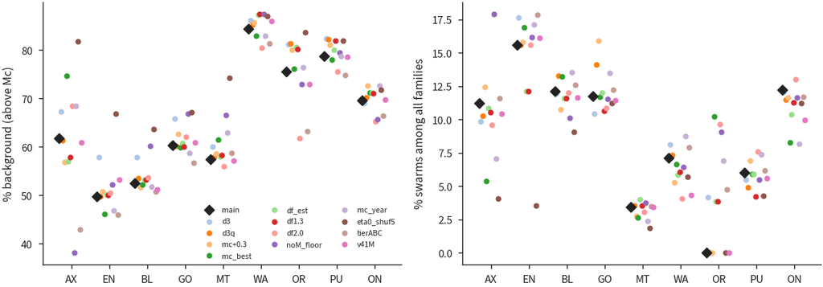

% background above Mc by variant:

| variant | region | d3 | d3q | df1.3 | df2.0 | df_est | eta0_shuf5 | main | mc+0.3 | mc_best | mc_year | noM_floor | tierABC | v41M |
| --- | --- | --- | --- | --- | --- | --- | --- | --- | --- | --- | --- | --- | --- | --- |
|  | AX | 67.3 | 61.4 | 57.9 | 68.5 | 57.0 | 81.8 | 61.8 | 56.8 | 74.7 | 68.4 | 38.1 | 42.9 | 60.9 |
|  | EN | 57.8 | 49.8 | 50.0 | 50.5 | 50.2 | 66.8 | 49.8 | 50.7 | 46.1 | 46.8 | 52.2 | 46.0 | 53.3 |
|  | BL | 57.9 | 53.5 | 53.2 | 53.6 | 53.3 | 63.6 | 52.5 | 51.7 | 52.2 | 51.8 | 60.2 | 50.8 | 51.2 |
|  | GO | 65.8 | 60.2 | 60.1 | 62.1 | 60.7 | 67.2 | 60.3 | 62.7 | 59.9 | 58.7 | 66.8 | 56.7 | 60.9 |
|  | MT | 60.1 | 57.9 | 58.3 | 56.0 | 58.0 | 74.3 | 57.5 | 58.6 | 61.5 | 63.0 | 66.6 | 58.8 | 57.1 |
|  | WA | 86.1 | 85.3 | 87.5 | 80.5 | 87.3 | 87.0 | 84.4 | 85.7 | 83.0 | 82.9 | 87.5 | 81.4 | 86.0 |
|  | OR | 81.2 | 81.4 | 80.2 | 61.8 | 80.7 | 83.7 | 75.6 | 80.1 | 76.2 | 76.5 | 72.9 | 63.2 | 73.0 |
|  | PU | 82.3 | 82.2 | 81.9 | 75.5 | 80.1 | 81.9 | 78.8 | 81.1 | 78.0 | 78.8 | 79.4 | 74.9 | 78.6 |
|  | ON | 69.1 | 70.2 | 71.0 | 65.3 | 71.2 | 71.8 | 69.6 | 72.7 | 71.2 | 72.6 | 65.7 | 66.4 | 69.7 |

Share of events (in both analysis sets) with the same background/clustered label as the main run:

| variant | region | d3 | d3q | df1.3 | df2.0 | df_est | eta0_shuf5 | mc+0.3 | mc_best | mc_year | noM_floor | tierABC | v41M |
| --- | --- | --- | --- | --- | --- | --- | --- | --- | --- | --- | --- | --- | --- |
|  | AX | 0.944 | 0.970 | 0.960 | 0.933 | 0.952 | 0.800 | 0.942 | 0.899 | 0.939 | 0.639 | 0.893 | 0.975 |
|  | EN | 0.913 | 1.000 | 0.991 | 0.993 | 0.989 | 0.830 | 0.958 | 0.962 | 0.993 | 0.978 | 0.982 | 0.973 |
|  | BL | 0.893 | 0.943 | 0.981 | 0.978 | 0.976 | 0.888 | 0.930 | 0.956 | 0.945 | 0.895 | 0.997 | 0.980 |
|  | GO | 0.893 | 0.964 | 0.987 | 0.977 | 0.982 | 0.931 | 0.925 | 0.898 | 0.951 | 0.937 | 0.997 | 0.987 |
|  | MT | 0.944 | 0.960 | 0.974 | 0.961 | 0.981 | 0.832 | 0.953 | 0.955 | 0.970 | 0.973 | 0.991 | 0.992 |
|  | WA | 0.972 | 0.972 | 0.969 | 0.958 | 0.972 | 0.975 | 0.947 | 0.965 | 0.983 | 0.962 | 0.987 | 0.955 |
|  | OR | 0.925 | 0.942 | 0.955 | 0.862 | 0.950 | 0.920 | 0.924 | 0.970 | 0.977 | 0.932 | 0.931 | 0.965 |
|  | PU | 0.960 | 0.961 | 0.968 | 0.967 | 0.986 | 0.968 | 0.924 | 0.989 | 0.985 | 0.991 | 0.995 | 0.981 |
|  | ON | 0.915 | 0.967 | 0.979 | 0.954 | 0.974 | 0.978 | 0.931 | 0.939 | 0.952 | 0.949 | 0.937 | 0.966 |

Number of swarms by variant:

| variant | region | d3 | d3q | df1.3 | df2.0 | df_est | eta0_shuf5 | main | mc+0.3 | mc_best | mc_year | noM_floor | tierABC | v41M |
| --- | --- | --- | --- | --- | --- | --- | --- | --- | --- | --- | --- | --- | --- | --- |
|  | AX | 32 | 38 | 41 | 30 | 43 | 9 | 40 | 24 | 36 | 34 | 359 | 34 | 37 |
|  | EN | 6 | 5 | 4 | 5 | 4 | 1 | 5 | 3 | 11 | 6 | 11 | 5 | 5 |
|  | BL | 70 | 77 | 66 | 69 | 66 | 44 | 70 | 28 | 118 | 125 | 134 | 71 | 60 |
|  | GO | 12 | 15 | 11 | 11 | 12 | 11 | 12 | 7 | 30 | 22 | 37 | 12 | 12 |
|  | MT | 12 | 13 | 12 | 13 | 14 | 5 | 13 | 5 | 18 | 15 | 30 | 12 | 13 |
|  | WA | 3 | 3 | 2 | 2 | 2 | 2 | 3 | 1 | 5 | 5 | 4 | 3 | 1 |
|  | OR | 1 | 0 | 1 | 3 | 1 | 0 | 0 | 0 | 4 | 2 | 6 | 1 | 0 |
|  | PU | 12 | 11 | 9 | 19 | 13 | 9 | 14 | 6 | 16 | 20 | 15 | 14 | 10 |
|  | ON | 41 | 41 | 39 | 49 | 36 | 38 | 43 | 23 | 64 | 80 | 68 | 28 | 39 |

Variants: `d3` 3-D distance with every depth; `d3q` 3-D only between two depth_good events; `mc+0.3`; `mc_best` the mag piece's Mc_best with b above it; `df_est`, `df1.3`, `df2.0` fractal dimension; `noM_floor` M = Mc for events without M; `mc_year` Mc per region and year; `eta0_shuf5` threshold passing 5% of shuffled links; `tierABC` tier D out of the analysis set; `v41M` v4.1 magnitudes.

The background/clustered label agrees with the main run for 86-100% of events under d3q, df, Mc and magnitude changes. 3-D distance with every depth (d3) raises the background share by up to 8.0 points; restricted to well-constrained depths (d3q) the change is at most 5.8 points, so with v5.1 depths 3-D distance would be usable for the depth_good events. The threshold is again the largest choice: the conservative eta0 raises the background share by 2.2-20.0 points, most in AX (+20), EN (+17), MT (+17). Taking tier D out lowers the Axial background share by 19 points and offshore Oregon by 12 points, where tier D is 42% of the events above Mc.

**Axial is the least robust region.** Its background share ranges over the variants from 38.1% (noM_floor) to 81.8% (eta0_shuf5). The variants that move it most: noM_floor 38.1% (M = Mc for the 13,008 Axial events without M, label agreement with the main run 63.9%), tierABC 42.9%, mc_best 74.7% (Mc 0.20 instead of 0.65) and eta0_shuf5 81.8%. With the null test above (a shuffled catalog reproduces 75% of the Axial links), the Axial clustered share should be read as a range of about 18-62%, most of it spatial concentration.

## Topology and tectonic setting

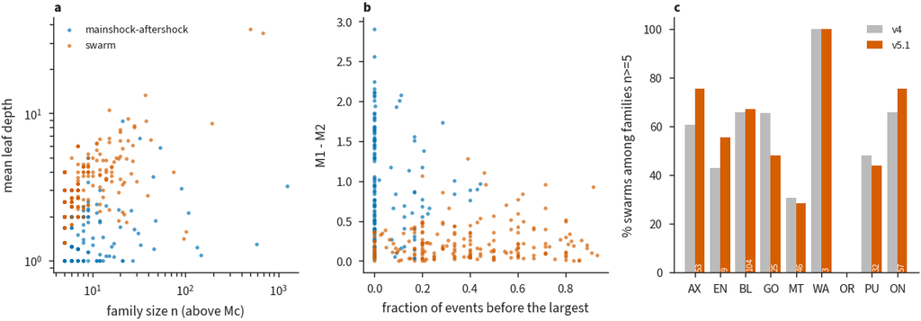

| region | families n≥5 | % swarms | v4 | median leaf depth | v4 | events Mc+1 to +2 | mean offspring | v4 | % no offspring | % ≥Mc+1 single | v4 | % MA with foreshocks | families n_all≥10 | % migrating |
| --- | --- | --- | --- | --- | --- | --- | --- | --- | --- | --- | --- | --- | --- | --- |
| AX | 53 | 75.50 | 60.60 | 3.00 | 2.67 | 670 | 0.65 | 0.85 | 58.70 | 31.80 | 21.00 | 28.10 | 59 | 0.00 |
| EN | 9 | 55.60 | 42.90 | 2.12 | 2.00 | 39 | 0.56 | 0.89 | 79.50 | 47.10 | 46.00 | 31.60 | 12 | 8.30 |
| BL | 104 | 67.30 | 66.00 | 2.50 | 2.50 | 328 | 1.90 | 1.80 | 53.00 | 39.30 | 37.50 | 31.50 | 133 | 0.00 |
| GO | 25 | 48.00 | 65.40 | 2.20 | 3.00 | 63 | 0.90 | 0.87 | 68.30 | 49.40 | 46.60 | 30.40 | 37 | 2.70 |
| MT | 46 | 28.30 | 30.60 | 1.56 | 1.33 | 588 | 0.51 | 0.40 | 72.30 | 44.00 | 44.40 | 19.70 | 58 | 0.00 |
| WA | 3 | 100.00 | 100.00 | 3.67 | 2.00 | 50 | 0.34 | 0.22 | 76.00 | 73.70 | 68.80 | 28.60 | 6 | 0.00 |
| OR | 3 | 0.00 | 0.00 | 2.00 | 1.57 | 39 | 0.38 | 0.29 | 76.90 | 62.80 | 56.80 | 46.70 | 3 | 0.00 |
| PU | 32 | 43.80 | 48.00 | 2.00 | 2.00 | 192 | 0.83 | 1.17 | 68.80 | 60.00 | 54.80 | 16.30 | 32 | 3.10 |
| ON | 57 | 75.40 | 65.90 | 2.50 | 2.83 | 622 | 0.39 | 0.34 | 76.00 | 58.90 | 60.10 | 31.70 | 52 | 1.90 |

## Families on the fault surfaces v1

Join with `fault_surfaces_v1_assignment.csv.gz` of the faults piece after its review fixes (142 surfaces, commit 6ebe0230 of analysis/v51-faults). An event is on a surface when the faults piece marks it `on_surface_strict`: a fit member, or a tier A-C event compatible with exactly one surface and within 2 km of it, without floor_limited, far_only or deep_pass. The first build also counted every 'assigned' event, of which 45% are tier D and 4,899 lie more than 5 km from their surface; that looser fraction is kept as `frac_on_faults_loose`. Axial Seamount was not fitted, so its events are neither on nor off a surface: fractions leave them out, and the 356 families with no member in a fitted region have no value. Half of the other 1,741 families have at least 67% of their events on a surface (swarms 71%, mainshock-aftershock 60%; loose join 75%). Rerun with `v51_clusters_zbz.py --steps faults` and this report if the surfaces change.

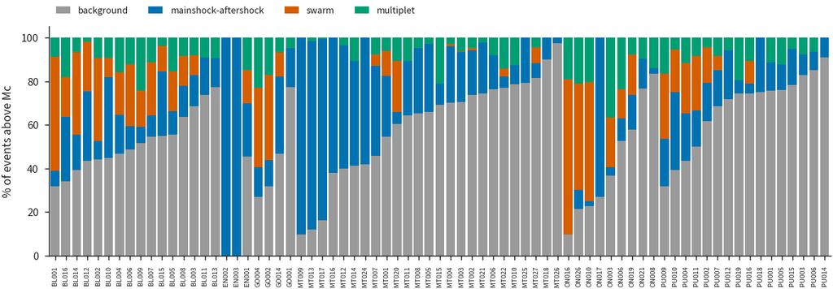

| surface_id | region | kind | stable | events ≥ Mc | pct_background | pct_swarm | n_families | swarm families | share of swarm events, largest family | share, two largest | v0 surfaces | flags (faults piece, shortened) | literature match (carried from v0, truncated) |
| --- | --- | --- | --- | --- | --- | --- | --- | --- | --- | --- | --- | --- | --- |
| v1_ON016 | ON | steep zone (fault candidate) | True | 42 | 9.50 | 71.40 | 5 | 2 | 0.50 | 1.00 | ON027 |  | Recurring swarms about 19 km N of Mount McLoughlin (east of |
| v1_ON010 | ON | steep zone (fault candidate) | True | 44 | 22.70 | 54.50 | 10 | 3 | 0.42 | 0.75 | ON015 |  | Mount Hood fault zone, Twin Lakes segment |
| v1_BL001 | BL | steep zone (fault candidate) | False | 1261 | 31.60 | 52.50 | 113 | 15 | 0.50 | 0.70 | BL004a;BL004b;BL006a;BL015a;BL018a | unstable in detection reruns | BL004b: West Blanco Depression transform zone, N member of t |
| v1_ON026 | ON | steep zone (fault candidate) | True | 33 | 21.20 | 48.50 | 11 | 4 | 0.50 | 0.75 |  | depth poorly constrained |  |
| v1_GO002 | GO | dipping zone | True | 41 | 31.70 | 39.00 | 14 | 5 | 0.56 | 0.75 | GO008 |  | Ridge axis at 42.28–42.52°N: Jackson segment, possibly its j |
| v1_BL014 | BL | steep zone (fault candidate) | True | 74 | 39.20 | 37.80 | 13 | 5 | 0.46 | 0.71 | BL004a;BL004b;BL006a;BL015a;BL018a | depth poorly constrained | BL015a: WBD near the RTI: S branch of Lange's two parallel c |
| v1_BL002 | BL | steep zone (fault candidate) | False | 812 | 44.10 | 37.80 | 88 | 19 | 0.55 | 0.69 | BL004a;BL004b;BL006a;BL015a;BL018a | unstable in detection reruns | BL006a: Surveyor Depression N-wall strand, continuing W into |
| v1_GO004 | GO | steep zone (fault candidate) | False | 74 | 27.00 | 36.50 | 17 | 3 | 0.70 | 0.89 | GO002;GO016 | unstable in detection reruns; members moved > 10 km in depth from v4 | GO002: Escanaba Trough axis, northern half (NESCA area); rid |
| v1_PU009 | PU | steep zone (fault candidate) | True | 138 | 31.90 | 29.70 | 20 | 3 | 0.66 | 0.88 | PU004 |  | No known counterpart, probably several clusters chained toge |
| v1_BL006 | BL | steep zone (fault candidate) | False | 285 | 48.80 | 28.40 | 43 | 10 | 0.31 | 0.53 | BL011b | unstable in detection reruns | Western tip of the Blanco Ridge, N-shifted strand next to CA |
| v1_PU011 | PU | dipping zone | False | 48 | 50.00 | 25.00 | 7 | 2 | 0.58 | 1.00 | PU001 | unstable in detection reruns | Diffuse mid-crustal Puget Lowland basement seismicity. SE en |
| v1_BL007 | BL | steep zone (fault candidate) | False | 255 | 54.50 | 24.30 | 42 | 10 | 0.48 | 0.66 | BL001b | unstable in detection reruns | Third (intra-basin) strand inside the Surveyor Depression |
| v1_MT020 | MT | dipping zone | False | 38 | 60.50 | 23.70 | 5 | 2 | 0.67 | 1.00 | MT025 | unstable in detection reruns | Gorda slab top / upper-slab seismicity beneath the Trinidad |
| v1_ON003 | ON | steep zone (fault candidate) | False | 79 | 36.70 | 22.80 | 28 | 6 | 0.28 | 0.56 | ON016;ON017 | unstable in detection reruns | ON017: SHZ segment south of the volcano \| ON016: MSH east fl |
| v1_PU004 | PU | steep zone (fault candidate) | False | 101 | 43.60 | 22.80 | 18 | 3 | 0.65 | 0.87 | PU002;PU014 | unstable in detection reruns | PU002: East-dipping western edge of seismogenic Crescent bas |

Highest swarm shares among the surfaces with 30 or more events above Mc (ranked from the table): v1_ON016 (ON, 71% of 42 events, 2 swarm families, the largest giving 50% of the swarm events); v1_ON010 (ON, 54% of 44 events, 3 swarm families, the largest giving 42% of the swarm events); v1_BL001 (BL, 52% of 1261 events, 15 swarm families, the largest giving 50% of the swarm events, unstable surface); v1_ON026 (ON, 48% of 33 events, 4 swarm families, the largest giving 50% of the swarm events); v1_GO002 (GO, 39% of 41 events, 5 swarm families, the largest giving 56% of the swarm events); v1_BL014 (BL, 38% of 74 events, 5 swarm families, the largest giving 46% of the swarm events); v1_BL002 (BL, 38% of 812 events, 19 swarm families, the largest giving 55% of the swarm events, unstable surface); v1_GO004 (GO, 36% of 74 events, 3 swarm families, the largest giving 70% of the swarm events, unstable surface). The swarm events of a surface are concentrated in few families: over the 39 surfaces with swarm events, the largest swarm family gives a median of 58% of them and the two largest 89%. The surfaces were also fitted to these same events, so a surface's swarm share is not an independent property of a fault: it mostly says which one or two swarms built the surface. 3 of these 8 surfaces are unstable in the faults piece's detection reruns.

**Flagged events.** The faults piece removed surfaces whose events occur mostly on weekday daytime (possible unflagged blasts). After its fix, the weekday-daytime members of those surfaces form their own class (884 events, the first build had 1,137 because it counted every member of the removed surfaces); here 112 of them are above Mc and 23 are in 16 families. They stay in the analysis because the catalog does not flag them; families holding them carry `n_daytime_screened` > 0 (16 families). Families with events of the waveform-review sets carry `n_review_P1_msh_deep` (32 families) and `n_review_P2_brookings` (4 families); the faults piece marks v1_ON028 (Mount St Helens deep population) and v1_GO022 (Brookings 2012) as not usable until that review is done.

## Proposed decisions for the PI

1. Run the main analysis on tier A-C events and attach tier D afterwards, as the PI chose for the fault surfaces; keep the all-tier run as a variant. Outside Axial, tier D epicentres have median errors of 9-45 km, 16% of the links have a tier D end, and the tierABC variant changes at most 6.9% of the labels outside Axial while it removes the 2014 Vancouver Island artefact. (Not applied here: the main run is unchanged from the first build.)
2. Report the null test (shuffled-to-real link ratio per region) with every clustered share, and give the Axial clustered share as a range (18-62%) rather than one number.
3. Leave the Mount St Helens deep events (review P1) out of the next run if the human review confirms that they are false events; until then their families are flagged.
4. Do these on catalog v6.0 (D-B079, NonLinLoc with SSST station terms), which supersedes v5.1, with 3-D distance restricted to well-constrained depths (d3q) as the main run, and relocate the swarms relatively (double difference) before interpreting migration or diffusivity.

## Limits and open issues

- Completeness changes in space and time. The constant regional Mc keeps 30,201 of 168,406 events in the analysis set; volcano microswarms and the Axial events below M 0.65 are only attached afterwards. The Mc rule depends on floating-point bin edges in 2 regions (BL, OR).
- The main run uses epicentral distance, so slab and crustal events that share an epicentre can link. With v5.1 depths the d3q variant (3-D only between well-constrained depths) changes few labels, so a 3-D main run is possible in a next version.
- Tier D epicentres enter the analysis set. Their median h_max is 4.8 km at Axial, 9 km at the Mendocino triple junction and 23-45 km elsewhere (EN 36, BL 28, GO 23, WA 45, OR 34, PU 38, ON 32); the five-phase events have 42 km. 16% of the links have a tier D end (48% in ON). Links between tier D events tens of km apart can be artefacts, as the 2014 Vancouver Island foreshock shows.
- Time-shuffled catalogs reproduce 21-75% of the links (75% at Axial), and within-month shuffles more. The clustered shares mix triggering with spatial concentration and slow rate changes.
- Location errors (median h_max 2.0 km for tier A-C swarm members) are as large as most swarms, so migration and sqrt(t) fits are unresolved for most families. Relative (double-difference) relocation of the swarms is needed before diffusivities can be interpreted.
- Magnitudes: in its own review the mag piece found that its phase19 station-term inversion stops at 3,000 iterations without converging; converged, ML would move by -0.68 on the Blanco, -0.51 in its Juan de Fuca region and -0.28 at Gorda, Mendocino and the offshore forearc (onshore +0.01) and agree better with ComCat offshore. Production M is unchanged (PI decision), so offshore Mc and M1-M2 here inherit that offset. Offshore ML is 0.3-0.5 above ComCat ML at Mendocino, Blanco and Gorda (mag piece); M1-M2 gaps of a few tenths drive the swarm and multiplet rules and are close to the ML uncertainty (about 0.2). 41,337 located earthquakes have no M and cannot be parents.
- Swarm criteria are thresholds on continuous properties; families near them switch type between versions (7% of the kept families changed type).
- Rate changes from network changes (OBS deployments 2011-2015, NC/BK pick gap in 2016) are not modelled; Mc is the worst yearly value per region to limit their effect.
- 884 weekday-daytime members of surfaces the faults piece removed for their timing are kept; they may be unflagged blasts (23 in 16 families, flag n_daytime_screened).
- Mount St Helens deep events (review P1): 159 above Mc, 77 in 32 families, 10 of which start on a Wednesday near local noon. They are probably false events from the weekly artificial signal on the analog UW channels; pending human review.
- Catalog v5.1 is located in model v0.3.1. The PI has adopted model v0.4.0 (v0.3.1 re-inverted with the re-timed picks, D-B082), v0.4.1 (with a surface floor in the inversion, D-B083) is being built, and catalog v6.0 (D-B079, NonLinLoc with SSST station terms) will supersede v5.1. These products will be redone on v6.0.

## Files

- `events_zbz_v51.csv.gz (worktree, slim) and /wd1/.../v5.1_analysis/clusters/events_zbz_v51.csv.gz (full)`: every catalog row: region box, in_analysis, M, parent_id, log_eta, log_T, log_R, nn_dist_km, nn_dt_days, linked, family_id, family_type, role, background, cls, excluded (full file adds time, lat, lon, depth, tier, flags)
- `families_zbz_v51.csv`: every family: type, size above Mc and in all, magnitude range, start/end, durations, extent, depth ranges (depth_good), depth_main_any_quality (any depth quality; see depth_main_good), swarm indicators, topology, v4-style migration, v5.1 migration (rho, Spearman and permutation p, radial speed, velocity vector and azimuth, vz), D90, D50, envelope exponent, resolvable, style, fault fractions (strict and loose, Axial left out), flags n_daytime_screened, n_review_P1_msh_deep, n_review_P2_brookings, v4 status
- `regions_zbz.csv, thresholds_zbz.csv, completeness_b_df.csv, completeness_by_year.csv`: per-region summary, mixture fits and thresholds, Mc and b
- `sensitivity_zbz.csv; /wd1/.../clusters/variants/`: variant summaries; per-variant event and family tables
- `shuffle_test.csv, shuffle_eta_seed0.npz`: time-shuffled catalogs
- `v4_families_status.csv, v51_families_status.csv, v4_v51_family_overlap.csv, v4_vs_v51_event_classes*.csv, v4_vs_v51_analysis_membership.csv, v4_dissolved_members_fate.csv`: comparison with v4
- `dbscan_clusters_v51.csv, dbscan_members_v51.csv, dbscan_v4_status.csv, dbscan_v51_status.csv`: DBSCAN swarm scan and its comparison with v4
- `validation_sequences.csv, volcano_families.csv, volcano_local_zbz.csv, volcano_local_families.csv, setting_stats.csv`: validation and setting tables
- `faults_v1_cluster_counts.csv, faults_v1_daytime_surfaces_events.csv`: fault surfaces v1 join
- `null_test.csv, null_test_summary.csv`: null test: time-shuffled catalogs at the real thresholds (links, D, families, swarms)
- `tierD_by_region.csv, mc_edge_check.csv, depth_swarm_vs_ma_families.csv`: tier D errors and links; Mc with float and exact bin edges; family-level depth test
- `review_sets_in_clusters.csv, review_P1_families.csv`: waveform-review sets P1-P4 in the clustering; families with Mount St Helens deep events
- `input_commits.json`: commits of the other pieces' products read by the run

## References

Reference list of the v4 clustering report (DOIs checked there against Crossref on 2026-11-22) plus Shapiro et al. (1997), whose DOI was not checked here.

- Aki, K. (1965). Maximum likelihood estimate of b in the formula log N = a - bM and its confidence limits. Bull. Earthq. Res. Inst. 43, 237-239.
- Baiesi, M., & Paczuski, M. (2004). Scale-free networks of earthquakes and aftershocks. Phys. Rev. E 69, 066106. [doi:10.1103/PhysRevE.69.066106](https://doi.org/10.1103/PhysRevE.69.066106)
- Boettcher, M. S., & McGuire, J. J. (2009). Scaling relations for seismic cycles on mid-ocean ridge transform faults. GRL 36, L21301. [doi:10.1029/2009GL040115](https://doi.org/10.1029/2009GL040115)
- Hsu, Y.-F., Martínez-Garzón, P., Trugman, D. T., & Ben-Zion, Y. (2026). Earthquake clustering and stress inversion in the Mendocino Triple Junction region. GJI 245(3), ggag089. (first author's initials not checked) [doi:10.1093/gji/ggag089](https://doi.org/10.1093/gji/ggag089)
- Kuna, V. M., Nábělek, J. L., & Braunmiller, J. (2019). Mode of slip and crust-mantle interaction at oceanic transform faults. Nat. Geosci. 12, 138-142. [doi:10.1038/s41561-018-0287-1](https://doi.org/10.1038/s41561-018-0287-1)
- McGuire, J. J., Boettcher, M. S., & Jordan, T. H. (2005). Foreshock sequences and short-term earthquake predictability on East Pacific Rise transform faults. Nature 434, 457-461. [doi:10.1038/nature03377](https://doi.org/10.1038/nature03377)
- Roland, E., & McGuire, J. J. (2009). Earthquake swarms on transform faults. GJI 178(3), 1677-1690. [doi:10.1111/j.1365-246X.2009.04214.x](https://doi.org/10.1111/j.1365-246X.2009.04214.x)
- Shapiro, S. A., Huenges, E., & Borm, G. (1997). Estimating the crust permeability from fluid-injection-induced seismic emission at the KTB site. GJI 131(2), F15-F18. [doi:10.1111/j.1365-246X.1997.tb01215.x](https://doi.org/10.1111/j.1365-246X.1997.tb01215.x)
- Vidale, J. E., & Shearer, P. M. (2006). A survey of 71 earthquake bursts across southern California. JGR 111, B05312. [doi:10.1029/2005JB004034](https://doi.org/10.1029/2005JB004034)
- Wells, D. L., & Coppersmith, K. J. (1994). New empirical relationships among magnitude, rupture length, rupture width, rupture area, and surface displacement. BSSA 84, 974-1002.
- Wilcock, W. S. D., et al. (2016). Seismic constraints on caldera dynamics from the 2015 Axial Seamount eruption. Science 354, 1395-1399. [doi:10.1126/science.aah5563](https://doi.org/10.1126/science.aah5563)
- Woessner, J., & Wiemer, S. (2005). Assessing the quality of earthquake catalogues: estimating the magnitude of completeness and its uncertainty. BSSA 95, 684-698.
- Zaliapin, I., Gabrielov, A., Keilis-Borok, V., & Wong, H. (2008). Clustering analysis of seismicity and aftershock identification. PRL 101, 018501. [doi:10.1103/PhysRevLett.101.018501](https://doi.org/10.1103/PhysRevLett.101.018501)
- Zaliapin, I., & Ben-Zion, Y. (2013a). Earthquake clusters in southern California I: Identification and stability. JGR 118, 2847-2864. [doi:10.1002/jgrb.50179](https://doi.org/10.1002/jgrb.50179)
- Zaliapin, I., & Ben-Zion, Y. (2013b). Earthquake clusters in southern California II: Classification and relation to physical properties of the crust. JGR 118, 2865-2877. [doi:10.1002/jgrb.50178](https://doi.org/10.1002/jgrb.50178)
- Zaliapin, I., & Ben-Zion, Y. (2016). A global classification and characterization of earthquake clusters. GJI 207(1), 608-634. [doi:10.1093/gji/ggw300](https://doi.org/10.1093/gji/ggw300)